# Bicycle Theft

```r
#Testing Model
risk_pred_rf_model_04<- predict(rf_model_04, data_1_test)


#Statistics about model
data_1_test$risk_pred_rf_model_04<- risk_pred_rf_model_04
conf_matrix_rf_model_04<- table(data_1_test$Hood_Risk, data_1_test$risk_pred_rf_model_04)
conf_matrix_rf_model_04
```

```
##
##             Very Low  Low Medium High Very High
##   Very Low        51    8     44    3         0
##   Low              2  237     13   25         0
##   Medium           0    0    547    7         1
##   High             0    1      0  959        22
##   Very High        0    0      0    1      5236
```

```r
class_accuarcy_rf_model_04<- sum(diag(conf_matrix_rf_model_04)/sum(conf_matrix_rf_model_04))
class_accuarcy_rf_model_04
```

```
## [1] 0.9822551
```

```r
confusionMatrix(conf_matrix_rf_model_04)
```

```
## Confusion Matrix and Statistics
##
##
##             Very Low  Low Medium High Very High
##   Very Low        51    8     44    3         0
##   Low              2  237     13   25         0
##   Medium           0    0    547    7         1
##   High             0    1      0  959        22
##   Very High        0    0      0    1      5236
##
## Overall Statistics
##
##                Accuracy : 0.9823
##                  95% CI : (0.9789, 0.9852)
##     No Information Rate : 0.7348
##     P-Value [Acc > NIR] : < 2.2e-16
##
##                   Kappa : 0.9592
##
##  Mcnemar's Test P-Value : NA
##
## Statistics by Class:
##
##                      Class: Very Low Class: Low Class: Medium Class: High
## Sensitivity                 0.962264    0.96341       0.90563      0.9638
## Specificity                 0.992258    0.99421       0.99878      0.9963
## Pos Pred Value              0.481132    0.85560       0.98559      0.9766
## Neg Pred Value              0.999716    0.99869       0.99137      0.9942
## Prevalence                  0.007405    0.03437       0.08439      0.1390
## Detection Rate              0.007126    0.03311       0.07643      0.1340
## Detection Prevalence        0.014811    0.03870       0.07755      0.1372
## Balanced Accuracy           0.977261    0.97881       0.95220      0.9800
##                      Class: Very High
## Sensitivity                    0.9956
## Specificity                    0.9995
## Pos Pred Value                 0.9998
## Neg Pred Value                 0.9880
## Prevalence                     0.7348
## Detection Rate                 0.7316
## Detection Prevalence           0.7317
## Balanced Accuracy              0.9975
```

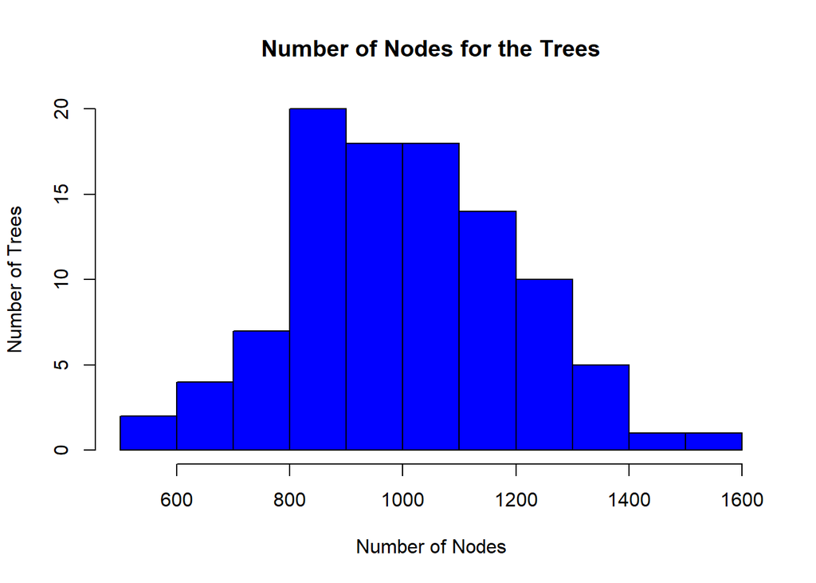

```r
hist(treesize(rf_model_04),ylim = c(0, 20) ,xlab = "Number of Nodes", ylab = "Number of Trees", main = "Number of Nodes for the Trees", col = "blue")
```

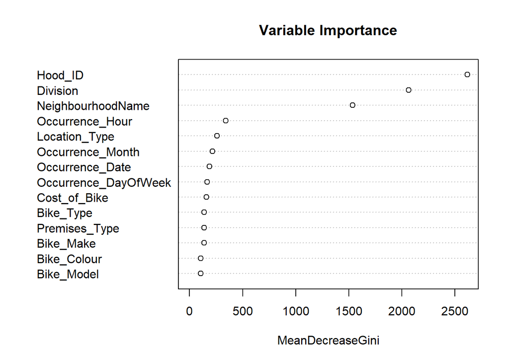

```r
varImpPlot(rf_model_04, sort = TRUE, main = "Variable Importance")
```

```r
importance(rf_model_04)
```

```
##                      MeanDecreaseGini
## NeighbourhoodName           1535.2469
## Occurrence_Date              186.5996
## Occurrence_Month             214.2604
## Occurrence_DayOfWeek         164.4120
## Occurrence_Hour              342.4182
## Division                    2064.4866
## Hood_ID                     2614.3122
## Location_Type                257.0823
## Premises_Type                137.6890
## Bike_Make                    136.6456
## Bike_Model                   106.1721
## Bike_Type                    138.1348
## Bike_Colour                  106.8218
## Cost_of_Bike                 158.4067
```

No Status No City No Primary_Offence No Occurrence_Year No Premises_Type No Bike_Model were used

```r
set.seed(999)
data_1<- bt_clean_future_selection

#Random Sampling
Index<- sample(nrow(data_1), floor(0.70*nrow(data_1)))
data_1_train<- data_1[Index,]
data_1_test<- data_1[-Index,]

#Treating train data
data_1_train$Cost_of_Bike[is.na(data_1_train$Cost_of_Bike)]<- mean(data_1_train$Cost_of_Bike,na.rm=TRUE)
data_1_train$Occurrence_Year[data_1_train$Occurrence_Year==2009] <- 2014
data_1_train$Occurrence_Year[data_1_train$Occurrence_Year==2010] <- 2014
data_1_train$Occurrence_Year[data_1_train$Occurrence_Year==2011] <- 2014
data_1_train$Occurrence_Year[data_1_train$Occurrence_Year==2012] <- 2014
data_1_train$Occurrence_Year[data_1_train$Occurrence_Year==2013] <- 2014

ctrl<- trainControl(method = "repeatedcv", number = 10 ,repeats = 10)

#Building model
rf_model_05<- randomForest(Hood_Risk~.-Status-City-Primary_Offence-Occurrence_Year-Premises_Type-Bike_Model, data = data_1_train, ntree = 100, trainControl = ctrl, tuneLength = 50)
print(rf_model_05)
```

```
##
## Call:
##  randomForest(formula = Hood_Risk ~ . - Status - City - Primary_Offence -      Occurrence_Year - Premises_Type - Bike_Model, data = data_1_train,      ntree = 100, trainControl = ctrl, tuneLength = 50)
##                Type of random forest: classification
##                      Number of trees: 100
## No. of variables tried at each split: 3
##
##         OOB estimate of  error rate: 1.2%
## Confusion matrix:
##           Very Low Low Medium High Very High  class.error
## Very Low       177  48     86    9         0 0.4468750000
## Low              6 639      9   27         1 0.0630498534
## Medium           0   2   1451   13         0 0.0102319236
## High             0   3      0 2579         9 0.0046314164
## Very High        0   0      0    2     12837 0.0001557754
```

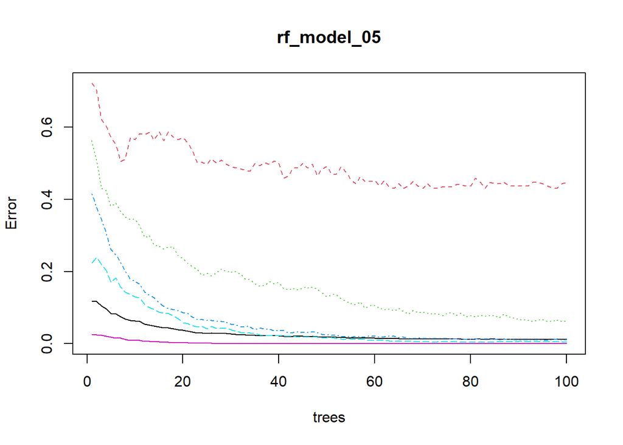

```r
plot(rf_model_05)
```

```r
#Testing Model
risk_pred_rf_model_05<- predict(rf_model_05, data_1_test)


#Statistics about model
data_1_test$risk_pred_rf_model_05<- risk_pred_rf_model_05
conf_matrix_rf_model_05<- table(data_1_test$Hood_Risk, data_1_test$risk_pred_rf_model_05)
conf_matrix_rf_model_05
```

```
##
##             Very Low  Low Medium High Very High
##   Very Low        60    6     37    3         0
##   Low              3  256      4   14         0
##   Medium           0    0    552    3         0
##   High             0    0      0  962        20
##   Very High        0    0      0    1      5236
```

```r
class_accuarcy_rf_model_05<- sum(diag(conf_matrix_rf_model_05)/sum(conf_matrix_rf_model_05))
class_accuarcy_rf_model_05
```

```
## [1] 0.9872852
```

```r
confusionMatrix(conf_matrix_rf_model_05)
```

```
## Confusion Matrix and Statistics
##
##
##             Very Low  Low Medium High Very High
##   Very Low        60    6     37    3         0
##   Low              3  256      4   14         0
##   Medium           0    0    552    3         0
##   High             0    0      0  962        20
##   Very High        0    0      0    1      5236
##
## Overall Statistics
##
##                Accuracy : 0.9873
##                  95% CI : (0.9844, 0.9898)
##     No Information Rate : 0.7344
##     P-Value [Acc > NIR] : < 2.2e-16
##
##                   Kappa : 0.9708
##
##  Mcnemar's Test P-Value : NA
##
## Statistics by Class:
##
##                      Class: Very Low Class: Low Class: Medium Class: High
## Sensitivity                 0.952381    0.97710       0.93086      0.9786
## Specificity                 0.993516    0.99695       0.99954      0.9968
## Pos Pred Value              0.566038    0.92419       0.99459      0.9796
## Neg Pred Value              0.999575    0.99913       0.99379      0.9966
## Prevalence                  0.008803    0.03661       0.08286      0.1373
## Detection Rate              0.008383    0.03577       0.07713      0.1344
## Detection Prevalence        0.014811    0.03870       0.07755      0.1372
## Balanced Accuracy           0.972948    0.98703       0.96520      0.9877
##                      Class: Very High
## Sensitivity                    0.9962
## Specificity                    0.9995
## Pos Pred Value                 0.9998
## Neg Pred Value                 0.9896
## Prevalence                     0.7344
## Detection Rate                 0.7316
## Detection Prevalence           0.7317
## Balanced Accuracy              0.9978
```

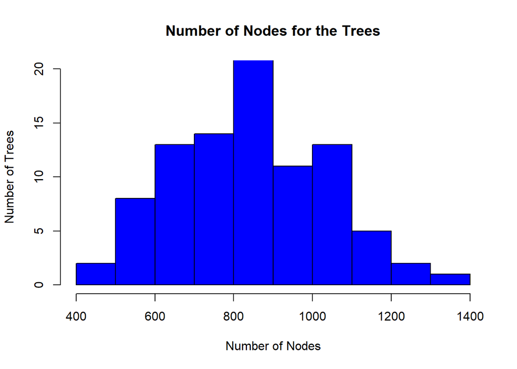

```r
hist(treesize(rf_model_05),ylim = c(0, 20) ,xlab = "Number of Nodes", ylab = "Number of Trees", main = "Number of Nodes for the Trees", col = "blue")
```

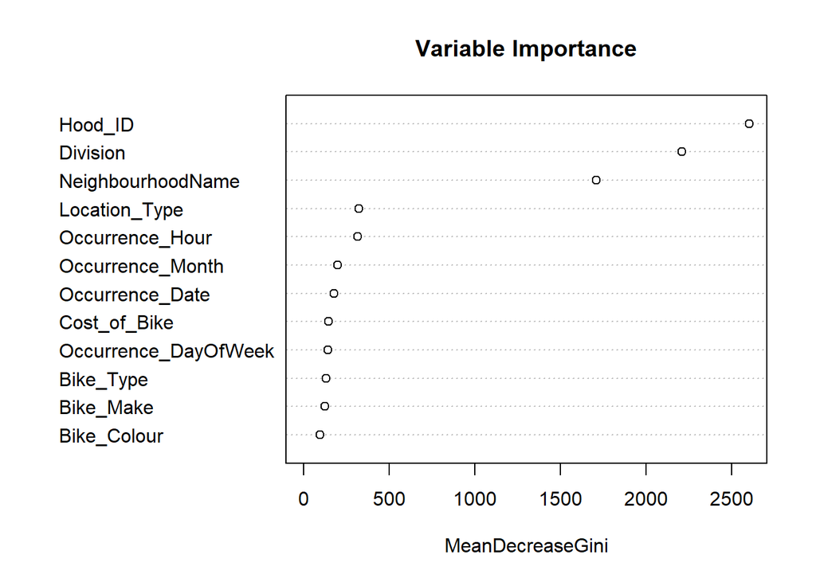

```r
varImpPlot(rf_model_05, sort = TRUE, main = "Variable Importance")
```

```r
importance(rf_model_05)
```

```
##                      MeanDecreaseGini
## NeighbourhoodName          1707.28590
## Occurrence_Date             175.48970
## Occurrence_Month            196.24906
## Occurrence_DayOfWeek        141.78012
## Occurrence_Hour             314.50501
## Division                   2207.48137
## Hood_ID                    2599.96063
## Location_Type               320.24043
## Bike_Make                   120.91384
## Bike_Type                   130.93550
## Bike_Colour                  94.73212
## Cost_of_Bike                142.06015
```

No Status No City No Primary_Offence No Occurrence_Year No Premises_Type No Bike_Model No Bike_Colour Variables were used

```r
set.seed(999)
data_1<- bt_clean_future_selection

#Random Sampling
Index<- sample(nrow(data_1), floor(0.70*nrow(data_1)))
data_1_train<- data_1[Index,]
data_1_test<- data_1[-Index,]

#Treating train data
data_1_train$Cost_of_Bike[is.na(data_1_train$Cost_of_Bike)]<- mean(data_1_train$Cost_of_Bike,na.rm=TRUE)
data_1_train$Occurrence_Year[data_1_train$Occurrence_Year==2009] <- 2014
data_1_train$Occurrence_Year[data_1_train$Occurrence_Year==2010] <- 2014
data_1_train$Occurrence_Year[data_1_train$Occurrence_Year==2011] <- 2014
data_1_train$Occurrence_Year[data_1_train$Occurrence_Year==2012] <- 2014
data_1_train$Occurrence_Year[data_1_train$Occurrence_Year==2013] <- 2014

ctrl<- trainControl(method = "repeatedcv", number = 10 ,repeats = 10)

#Building model
rf_model_06<- randomForest(Hood_Risk~.-Status-City-Primary_Offence-Occurrence_Year-Premises_Type-Bike_Model-Bike_Colour, data = data_1_train, ntree = 100, trainControl = ctrl, tuneLength = 50)
print(rf_model_06)
```

```
##
## Call:
##  randomForest(formula = Hood_Risk ~ . - Status - City - Primary_Offence -      Occurrence_Year - Premises_Type - Bike_Model - Bike_Colour,      data = data_1_train, ntree = 100, trainControl = ctrl, tuneLength = 50)
##                Type of random forest: classification
##                      Number of trees: 100
## No. of variables tried at each split: 3
##
##         OOB estimate of  error rate: 0.9%
## Confusion matrix:
##           Very Low Low Medium High Very High  class.error
## Very Low       206  37     73    4         0 3.562500e-01
## Low              9 649      9   14         1 4.838710e-02
## Medium           0   0   1461    5         0 3.410641e-03
## High             0   1      2 2583         5 3.087611e-03
## Very High        0   0      0    1     12838 7.788769e-05
```

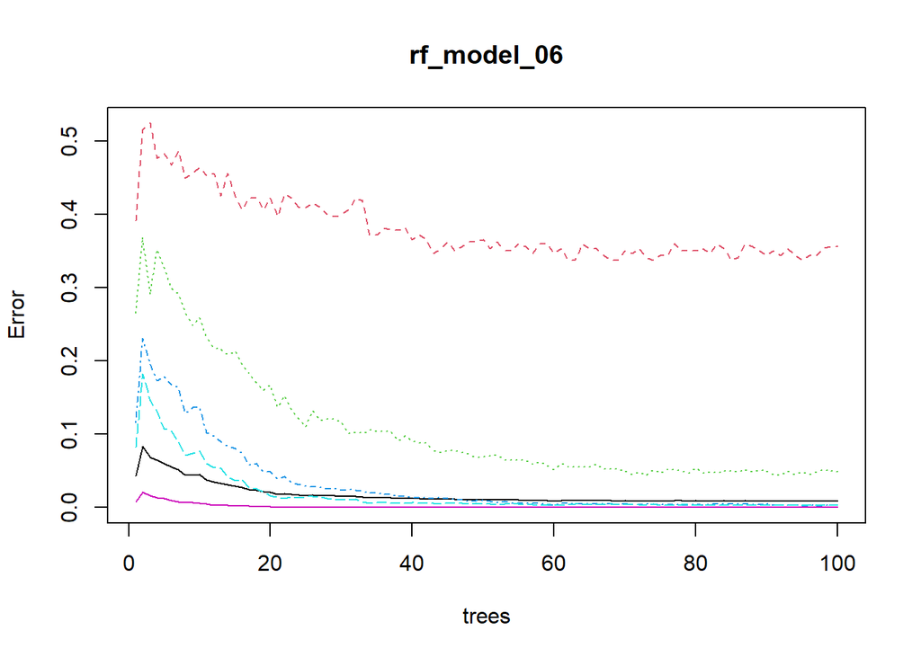

```r
plot(rf_model_06)
```

```r
#Testing Model
risk_pred_rf_model_06<- predict(rf_model_06, data_1_test)


#Statistics about model
data_1_test$risk_pred_rf_model_06<- risk_pred_rf_model_06
conf_matrix_rf_model_06<- table(data_1_test$Hood_Risk, data_1_test$risk_pred_rf_model_06)
conf_matrix_rf_model_06
```

```
##
##             Very Low  Low Medium High Very High
##   Very Low        72    5     29    0         0
##   Low              1  266      1    9         0
##   Medium           0    0    555    0         0
##   High             0    0      1  967        14
##   Very High        0    0      0    1      5236
```

```r
class_accuarcy_rf_model_06<- sum(diag(conf_matrix_rf_model_06)/sum(conf_matrix_rf_model_06))
class_accuarcy_rf_model_06
```

```
## [1] 0.9914769
```

```r
confusionMatrix(conf_matrix_rf_model_06)
```

```
## Confusion Matrix and Statistics
##
##
##             Very Low  Low Medium High Very High
##   Very Low        72    5     29    0         0
##   Low              1  266      1    9         0
##   Medium           0    0    555    0         0
##   High             0    0      1  967        14
##   Very High        0    0      0    1      5236
##
## Overall Statistics
##
##                Accuracy : 0.9915
##                  95% CI : (0.9891, 0.9935)
##     No Information Rate : 0.7335
##     P-Value [Acc > NIR] : < 2.2e-16
##
##                   Kappa : 0.9805
##
##  Mcnemar's Test P-Value : NA
##
## Statistics by Class:
##
##                      Class: Very Low Class: Low Class: Medium Class: High
## Sensitivity                  0.98630    0.98155       0.94710      0.9898
## Specificity                  0.99520    0.99840       1.00000      0.9976
## Pos Pred Value               0.67925    0.96029       1.00000      0.9847
## Neg Pred Value               0.99986    0.99927       0.99530      0.9984
## Prevalence                   0.01020    0.03787       0.08188      0.1365
## Detection Rate               0.01006    0.03717       0.07755      0.1351
## Detection Prevalence         0.01481    0.03870       0.07755      0.1372
## Balanced Accuracy            0.99075    0.98998       0.97355      0.9937
##                      Class: Very High
## Sensitivity                    0.9973
## Specificity                    0.9995
## Pos Pred Value                 0.9998
## Neg Pred Value                 0.9927
## Prevalence                     0.7335
## Detection Rate                 0.7316
## Detection Prevalence           0.7317
## Balanced Accuracy              0.9984
```

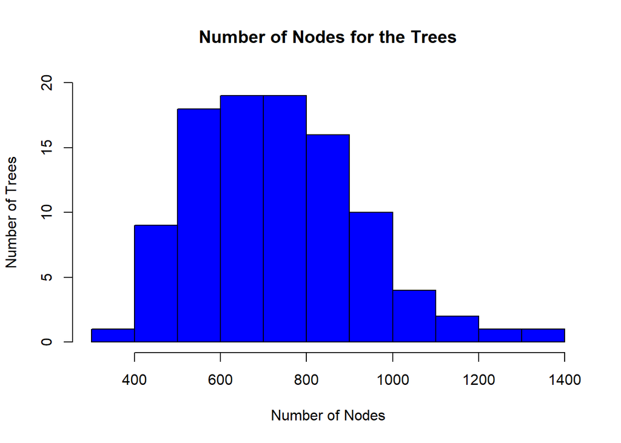

```r
hist(treesize(rf_model_06),ylim = c(0, 20) ,xlab = "Number of Nodes", ylab = "Number of Trees", main = "Number of Nodes for the Trees", col = "blue")
```

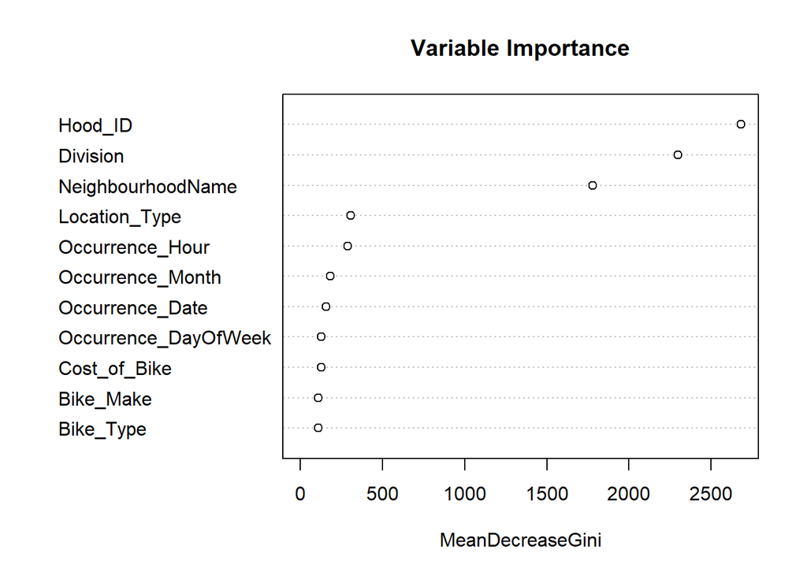

```r
varImpPlot(rf_model_06, sort = TRUE, main = "Variable Importance")
```

```r
importance(rf_model_06)
```

```
##                      MeanDecreaseGini
## NeighbourhoodName           1781.1902
## Occurrence_Date              155.3584
## Occurrence_Month             179.9351
## Occurrence_DayOfWeek         127.8483
## Occurrence_Hour              286.4447
## Division                    2299.6910
## Hood_ID                     2681.2173
## Location_Type                305.9542
## Bike_Make                    108.1910
## Bike_Type                    107.7688
## Cost_of_Bike                 125.5215
```

No Status No City No Primary_Offence No Occurrence_Year No Premises_Type No Bike_Model No Bike_Colour Bike_Type No Bike_Make Variables were used

```r
set.seed(999)
data_1<- bt_clean_future_selection

#Random Sampling
Index<- sample(nrow(data_1), floor(0.70*nrow(data_1)))
data_1_train<- data_1[Index,]
data_1_test<- data_1[-Index,]

#Treating train data
data_1_train$Cost_of_Bike[is.na(data_1_train$Cost_of_Bike)]<- mean(data_1_train$Cost_of_Bike,na.rm=TRUE)
data_1_train$Occurrence_Year[data_1_train$Occurrence_Year==2009] <- 2014
data_1_train$Occurrence_Year[data_1_train$Occurrence_Year==2010] <- 2014
data_1_train$Occurrence_Year[data_1_train$Occurrence_Year==2011] <- 2014
data_1_train$Occurrence_Year[data_1_train$Occurrence_Year==2012] <- 2014
data_1_train$Occurrence_Year[data_1_train$Occurrence_Year==2013] <- 2014

ctrl<- trainControl(method = "repeatedcv", number = 10 ,repeats = 10)

#Building model
rf_model_07<- randomForest(Hood_Risk~.-Status-City-Primary_Offence-Occurrence_Year-Premises_Type-Bike_Model-Bike_Colour-Bike_Type-Bike_Make, data = data_1_train, ntree = 100, trainControl = ctrl, tuneLength = 50)
print(rf_model_07)
```

```
##
## Call:
##  randomForest(formula = Hood_Risk ~ . - Status - City - Primary_Offence -      Occurrence_Year - Premises_Type - Bike_Model - Bike_Colour -      Bike_Type - Bike_Make, data = data_1_train, ntree = 100,      trainControl = ctrl, tuneLength = 50)
##                Type of random forest: classification
##                      Number of trees: 100
## No. of variables tried at each split: 3
##
##         OOB estimate of  error rate: 0.35%
## Confusion matrix:
##           Very Low Low Medium High Very High  class.error
## Very Low       271  18     30    1         0 1.531250e-01
## Low              3 672      2    5         0 1.466276e-02
## Medium           0   0   1466    0         0 0.000000e+00
## High             0   0      0 2589         2 7.719027e-04
## Very High        0   0      0    1     12838 7.788769e-05
```

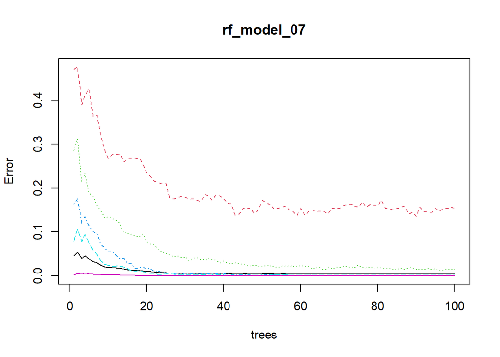

```r
plot(rf_model_07)
```

```r
#Testing Model
risk_pred_rf_model_07<- predict(rf_model_07, data_1_test)


#Statistics about model
data_1_test$risk_pred_rf_model_07<- risk_pred_rf_model_07
conf_matrix_rf_model_07<- table(data_1_test$Hood_Risk, data_1_test$risk_pred_rf_model_07)
conf_matrix_rf_model_07
```

```
##
##             Very Low  Low Medium High Very High
##   Very Low        93    3     10    0         0
##   Low              0  275      0    2         0
##   Medium           0    0    555    0         0
##   High             0    0      0  955        27
##   Very High        0    0      0    1      5236
```

```r
class_accuarcy_rf_model_07<- sum(diag(conf_matrix_rf_model_07)/sum(conf_matrix_rf_model_07))
class_accuarcy_rf_model_07
```

```
## [1] 0.9939919
```

```r
confusionMatrix(conf_matrix_rf_model_07)
```

```
## Confusion Matrix and Statistics
##
##
##             Very Low  Low Medium High Very High
##   Very Low        93    3     10    0         0
##   Low              0  275      0    2         0
##   Medium           0    0    555    0         0
##   High             0    0      0  955        27
##   Very High        0    0      0    1      5236
##
## Overall Statistics
##
##                Accuracy : 0.994
##                  95% CI : (0.9919, 0.9956)
##     No Information Rate : 0.7354
##     P-Value [Acc > NIR] : < 2.2e-16
##
##                   Kappa : 0.9862
##
##  Mcnemar's Test P-Value : NA
##
## Statistics by Class:
##
##                      Class: Very Low Class: Low Class: Medium Class: High
## Sensitivity                  1.00000    0.98921       0.98230      0.9969
## Specificity                  0.99816    0.99971       1.00000      0.9956
## Pos Pred Value               0.87736    0.99278       1.00000      0.9725
## Neg Pred Value               1.00000    0.99956       0.99849      0.9995
## Prevalence                   0.01299    0.03884       0.07894      0.1339
## Detection Rate               0.01299    0.03842       0.07755      0.1334
## Detection Prevalence         0.01481    0.03870       0.07755      0.1372
## Balanced Accuracy            0.99908    0.99446       0.99115      0.9963
##                      Class: Very High
## Sensitivity                    0.9949
## Specificity                    0.9995
## Pos Pred Value                 0.9998
## Neg Pred Value                 0.9859
## Prevalence                     0.7354
## Detection Rate                 0.7316
## Detection Prevalence           0.7317
## Balanced Accuracy              0.9972
```

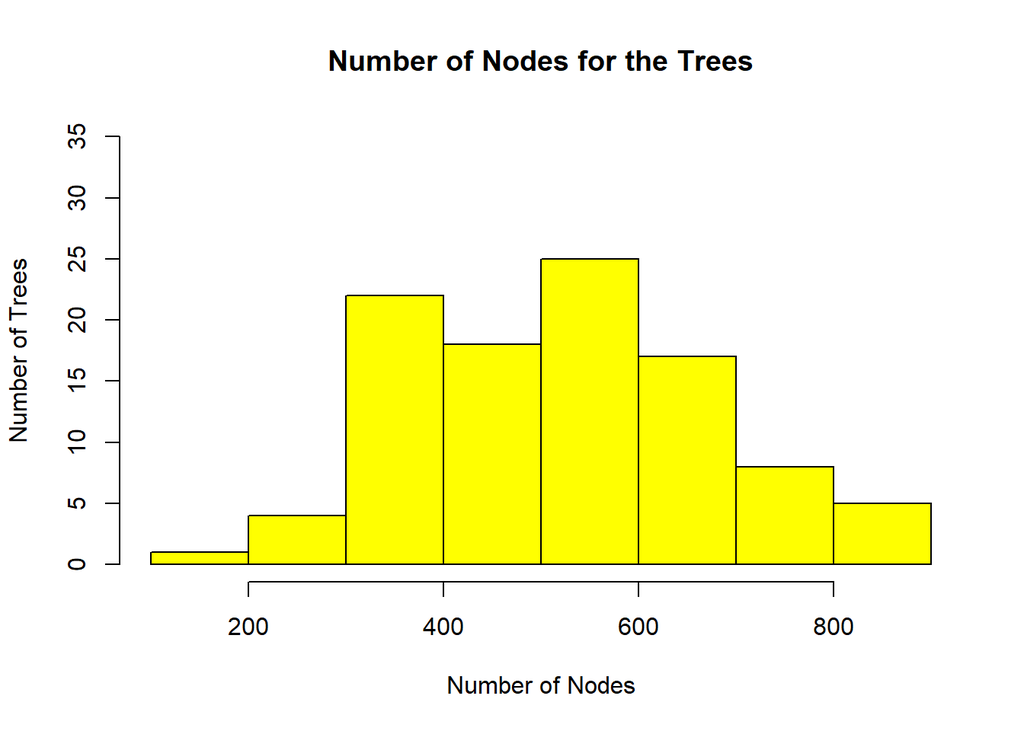

```r
hist(treesize(rf_model_07),ylim = c(0, 35) ,xlab = "Number of Nodes", ylab = "Number of Trees", main = "Number of Nodes for the Trees", col = "yellow")
```

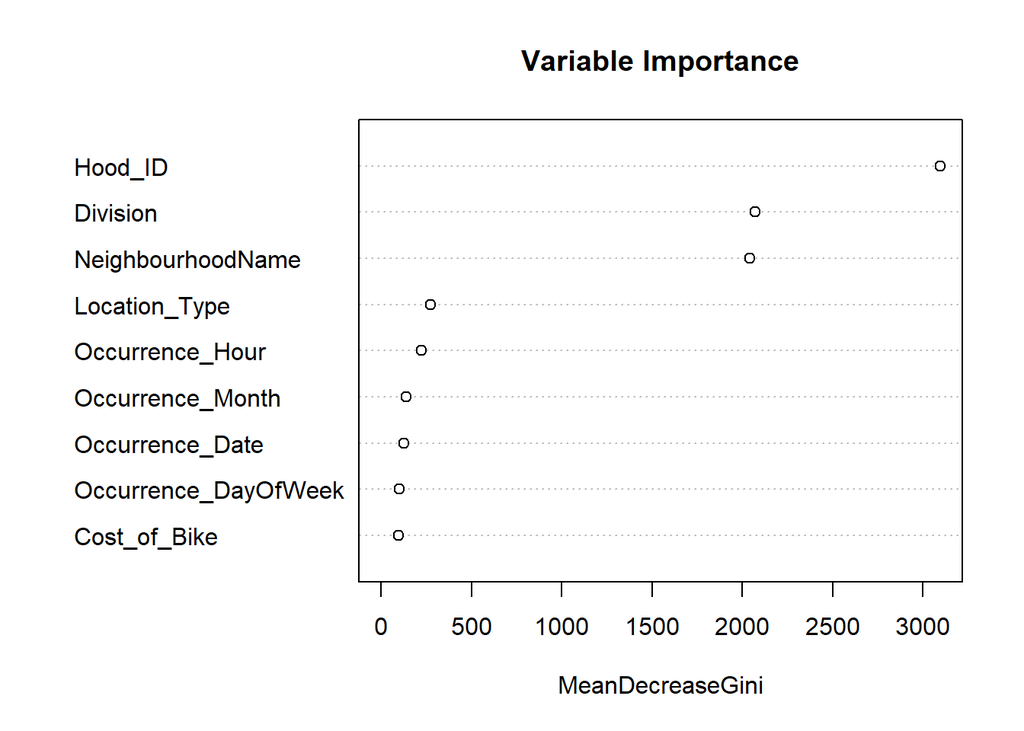

```r
varImpPlot(rf_model_07, sort = TRUE, main = "Variable Importance")
```

```r
importance(rf_model_07)
```

```
##                      MeanDecreaseGini
## NeighbourhoodName           2041.7608
## Occurrence_Date              122.5840
## Occurrence_Month             135.3431
## Occurrence_DayOfWeek         100.9178
## Occurrence_Hour              221.5563
## Division                    2068.8253
## Hood_ID                     3093.2227
## Location_Type                274.1665
## Cost_of_Bike                  95.6435
```

```r
#Model preformance calculations
n_conf_matrix_rf_model_07 = sum(conf_matrix_rf_model_07)
nc_conf_matrix_rf_model_07 = nrow(conf_matrix_rf_model_07)
diag_conf_matrix_rf_model_07 = diag(conf_matrix_rf_model_07)
rowsums_conf_matrix_rf_model_07 = apply(conf_matrix_rf_model_07, 1, sum)
colsums_conf_matrix_rf_model_07 = apply(conf_matrix_rf_model_07, 2, sum)

precision_conf_matrix_rf_model_07 = diag_conf_matrix_rf_model_07 / colsums_conf_matrix_rf_model_07
recall_conf_matrix_rf_model_07 = diag_conf_matrix_rf_model_07 / rowsums_conf_matrix_rf_model_07
f1_conf_matrix_rf_model_07 = 2 * precision_conf_matrix_rf_model_07 * recall_conf_matrix_rf_model_07 / (precision_conf_matrix_rf_model_07 + recall_conf_matrix_rf_model_07)
data_frame_conf_matrix_rf_model_07<- data.frame(precision_conf_matrix_rf_model_07, recall_conf_matrix_rf_model_07, f1_conf_matrix_rf_model_07)
data_frame_conf_matrix_rf_model_07
```

```
##           precision_conf_matrix_rf_model_07 recall_conf_matrix_rf_model_07
## Very Low                          1.0000000                      0.8773585
## Low                               0.9892086                      0.9927798
## Medium                            0.9823009                      1.0000000
## High                              0.9968685                      0.9725051
## Very High                         0.9948698                      0.9998091
##           f1_conf_matrix_rf_model_07
## Very Low                   0.9346734
## Low                        0.9909910
## Medium                     0.9910714
## High                       0.9845361
## Very High                  0.9973333
```

No Division Variable were used

```r
set.seed(999)
data_1<- bt_clean_future_selection

#Random Sampling
Index<- sample(nrow(data_1), floor(0.70*nrow(data_1)))
data_1_train<- data_1[Index,]
data_1_test<- data_1[-Index,]

#Treating train data
data_1_train$Cost_of_Bike[is.na(data_1_train$Cost_of_Bike)]<- mean(data_1_train$Cost_of_Bike,na.rm=TRUE)
data_1_train$Occurrence_Year[data_1_train$Occurrence_Year==2009] <- 2014
data_1_train$Occurrence_Year[data_1_train$Occurrence_Year==2010] <- 2014
data_1_train$Occurrence_Year[data_1_train$Occurrence_Year==2011] <- 2014
data_1_train$Occurrence_Year[data_1_train$Occurrence_Year==2012] <- 2014
data_1_train$Occurrence_Year[data_1_train$Occurrence_Year==2013] <- 2014

ctrl<- trainControl(method = "repeatedcv", number = 10 ,repeats = 10)

#Building model
rf_model_08<- randomForest(Hood_Risk~.-Division, data = data_1_train, ntree = 100, trainControl = ctrl, tuneLength = 50)
print(rf_model_08)
```

```
##
## Call:
##  randomForest(formula = Hood_Risk ~ . - Division, data = data_1_train,      ntree = 100, trainControl = ctrl, tuneLength = 50)
##                Type of random forest: classification
##                      Number of trees: 100
## No. of variables tried at each split: 4
##
##         OOB estimate of  error rate: 5.52%
## Confusion matrix:
##           Very Low Low Medium High Very High class.error
## Very Low        54  32    164   53        17 0.831250000
## Low              5 409    101  141        26 0.400293255
## Medium           1  31   1322   58        54 0.098226467
## High             0  33     65 2303       190 0.111153995
## Very High        0   1     11    5     12822 0.001324091
```

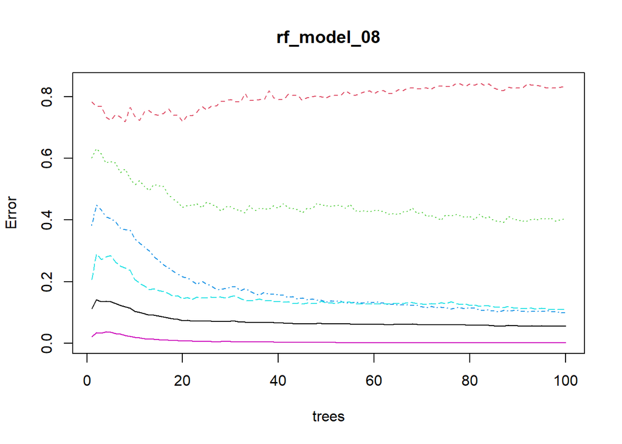

```r
plot(rf_model_08)
```

```r
#Testing Model
risk_pred_rf_model_08<- predict(rf_model_08, data_1_test)


#Statistics about model
data_1_test$risk_pred_rf_model_08<- risk_pred_rf_model_08
conf_matrix_rf_model_08<- table(data_1_test$Hood_Risk, data_1_test$risk_pred_rf_model_08)
conf_matrix_rf_model_08
```

```
##
##             Very Low  Low Medium High Very High
##   Very Low        15    8     67   13         3
##   Low              0  160     66   46         5
##   Medium           0    1    504   12        38
##   High             0    5     58  800       119
##   Very High        0    0     21    4      5212
```

```r
class_accuarcy_rf_model_08<- sum(diag(conf_matrix_rf_model_08)/sum(conf_matrix_rf_model_08))
class_accuarcy_rf_model_08
```

```
## [1] 0.9348889
```

```r
confusionMatrix(conf_matrix_rf_model_08)
```

```
## Confusion Matrix and Statistics
##
##
##             Very Low  Low Medium High Very High
##   Very Low        15    8     67   13         3
##   Low              0  160     66   46         5
##   Medium           0    1    504   12        38
##   High             0    5     58  800       119
##   Very High        0    0     21    4      5212
##
## Overall Statistics
##
##                Accuracy : 0.9349
##                  95% CI : (0.9289, 0.9405)
##     No Information Rate : 0.7513
##     P-Value [Acc > NIR] : < 2.2e-16
##
##                   Kappa : 0.8467
##
##  Mcnemar's Test P-Value : < 2.2e-16
##
## Statistics by Class:
##
##                      Class: Very Low Class: Low Class: Medium Class: High
## Sensitivity                 1.000000    0.91954       0.70391      0.9143
## Specificity                 0.987258    0.98325       0.99208      0.9710
## Pos Pred Value              0.141509    0.57762       0.90811      0.8147
## Neg Pred Value              1.000000    0.99797       0.96789      0.9879
## Prevalence                  0.002096    0.02431       0.10004      0.1223
## Detection Rate              0.002096    0.02236       0.07042      0.1118
## Detection Prevalence        0.014811    0.03870       0.07755      0.1372
## Balanced Accuracy           0.993629    0.95139       0.84800      0.9427
##                      Class: Very High
## Sensitivity                    0.9693
## Specificity                    0.9860
## Pos Pred Value                 0.9952
## Neg Pred Value                 0.9141
## Prevalence                     0.7513
## Detection Rate                 0.7282
## Detection Prevalence           0.7317
## Balanced Accuracy              0.9776
```

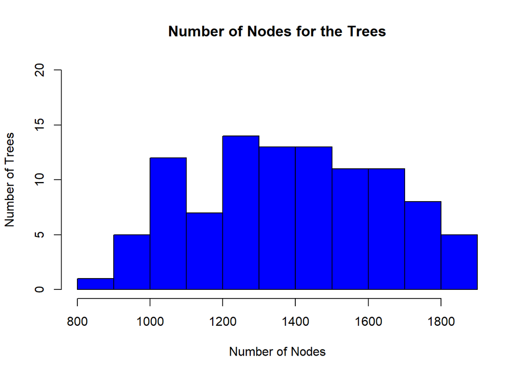

```r
hist(treesize(rf_model_08),ylim = c(0, 20) ,xlab = "Number of Nodes", ylab = "Number of Trees", main = "Number of Nodes for the Trees", col = "blue")
```

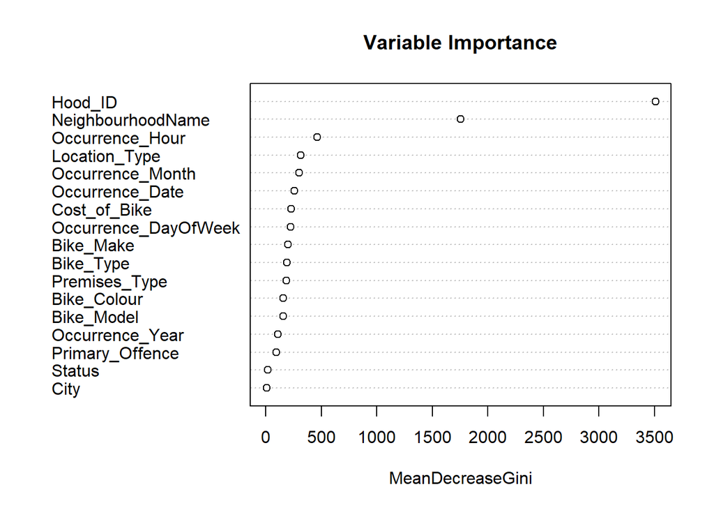

```r
varImpPlot(rf_model_08, sort = TRUE, main = "Variable Importance")
```

```r
importance(rf_model_08)
```

```
##                      MeanDecreaseGini
## NeighbourhoodName         1753.099909
## Primary_Offence             91.211888
## Occurrence_Date            255.397335
## Occurrence_Year            106.617201
## Occurrence_Month           298.900265
## Occurrence_DayOfWeek       224.220408
## Occurrence_Hour            461.747425
## City                         5.541899
## Hood_ID                   3508.061636
## Location_Type              314.743563
## Premises_Type              183.713353
## Bike_Make                  200.040784
## Bike_Model                 154.936493
## Bike_Type                  189.522088
## Bike_Colour                155.703879
## Cost_of_Bike               226.740532
## Status                      15.620420
```

No NeighbourhoodName Variable were used

```r
set.seed(999)
data_1<- bt_clean_future_selection

#Random Sampling
Index<- sample(nrow(data_1), floor(0.70*nrow(data_1)))
data_1_train<- data_1[Index,]
data_1_test<- data_1[-Index,]

#Treating train data
data_1_train$Cost_of_Bike[is.na(data_1_train$Cost_of_Bike)]<- mean(data_1_train$Cost_of_Bike,na.rm=TRUE)
data_1_train$Occurrence_Year[data_1_train$Occurrence_Year==2009] <- 2014
data_1_train$Occurrence_Year[data_1_train$Occurrence_Year==2010] <- 2014
data_1_train$Occurrence_Year[data_1_train$Occurrence_Year==2011] <- 2014
data_1_train$Occurrence_Year[data_1_train$Occurrence_Year==2012] <- 2014
data_1_train$Occurrence_Year[data_1_train$Occurrence_Year==2013] <- 2014

ctrl<- trainControl(method = "repeatedcv", number = 10 ,repeats = 10)

#Building model
rf_model_09<- randomForest(Hood_Risk~.-NeighbourhoodName, data = data_1_train, ntree = 100, trainControl = ctrl, tuneLength = 50)
print(rf_model_09)
```

```
##
## Call:
##  randomForest(formula = Hood_Risk ~ . - NeighbourhoodName, data = data_1_train,      ntree = 100, trainControl = ctrl, tuneLength = 50)
##                Type of random forest: classification
##                      Number of trees: 100
## No. of variables tried at each split: 4
##
##         OOB estimate of  error rate: 7.75%
## Confusion matrix:
##           Very Low Low Medium High Very High class.error
## Very Low        93  40    152   27         8 0.709375000
## Low              8 340    148  169        17 0.501466276
## Medium           4  23   1176  208        55 0.197817190
## High             1  15     85 2177       313 0.159783867
## Very High        0   1     30   83     12725 0.008879196
```

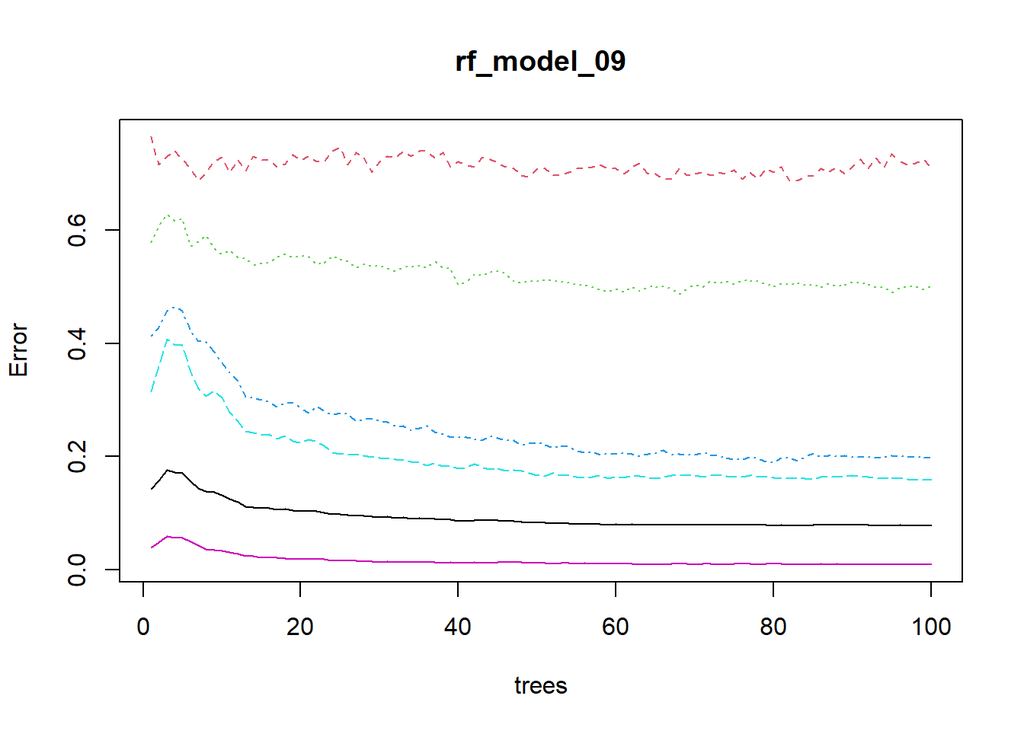

```r
plot(rf_model_09)
```

```r
#Testing Model
risk_pred_rf_model_09<- predict(rf_model_09, data_1_test)


#Statistics about model
data_1_test$risk_pred_rf_model_09<- risk_pred_rf_model_09
conf_matrix_rf_model_09<- table(data_1_test$Hood_Risk, data_1_test$risk_pred_rf_model_09)
conf_matrix_rf_model_09
```

```
##
##             Very Low  Low Medium High Very High
##   Very Low        21    9     65    9         2
##   Low              2  104     83   85         3
##   Medium           0    8    444   75        28
##   High             0    0     29  841       112
##   Very High        0    0     13   42      5182
```

```r
class_accuarcy_rf_model_09<- sum(diag(conf_matrix_rf_model_09)/sum(conf_matrix_rf_model_09))
class_accuarcy_rf_model_09
```

```
## [1] 0.9210563
```

```r
confusionMatrix(conf_matrix_rf_model_09)
```

```
## Confusion Matrix and Statistics
##
##
##             Very Low  Low Medium High Very High
##   Very Low        21    9     65    9         2
##   Low              2  104     83   85         3
##   Medium           0    8    444   75        28
##   High             0    0     29  841       112
##   Very High        0    0     13   42      5182
##
## Overall Statistics
##
##                Accuracy : 0.9211
##                  95% CI : (0.9146, 0.9272)
##     No Information Rate : 0.7443
##     P-Value [Acc > NIR] : < 2.2e-16
##
##                   Kappa : 0.8154
##
##  Mcnemar's Test P-Value : < 2.2e-16
##
## Statistics by Class:
##
##                      Class: Very Low Class: Low Class: Medium Class: High
## Sensitivity                 0.913043    0.85950       0.70032      0.7994
## Specificity                 0.988085    0.97541       0.98298      0.9769
## Pos Pred Value              0.198113    0.37545       0.80000      0.8564
## Neg Pred Value              0.999716    0.99753       0.97122      0.9658
## Prevalence                  0.003214    0.01691       0.08858      0.1470
## Detection Rate              0.002934    0.01453       0.06204      0.1175
## Detection Prevalence        0.014811    0.03870       0.07755      0.1372
## Balanced Accuracy           0.950564    0.91746       0.84165      0.8882
##                      Class: Very High
## Sensitivity                    0.9728
## Specificity                    0.9699
## Pos Pred Value                 0.9895
## Neg Pred Value                 0.9245
## Prevalence                     0.7443
## Detection Rate                 0.7240
## Detection Prevalence           0.7317
## Balanced Accuracy              0.9714
```

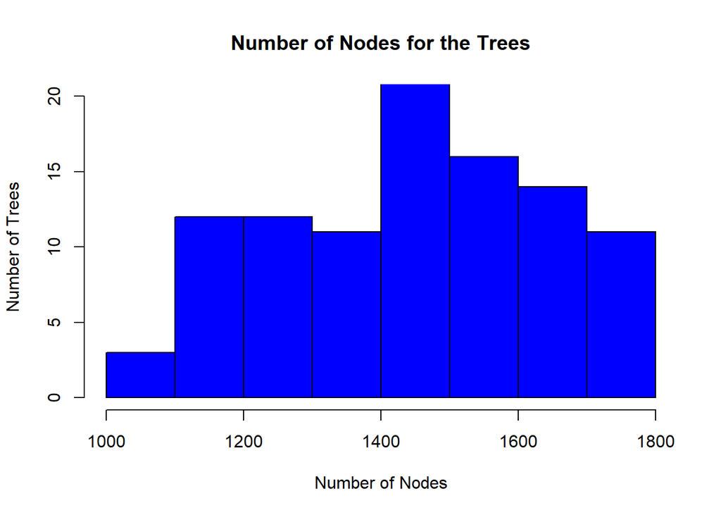

```r
hist(treesize(rf_model_09),ylim = c(0, 20) ,xlab = "Number of Nodes", ylab = "Number of Trees", main = "Number of Nodes for the Trees", col = "blue")
```

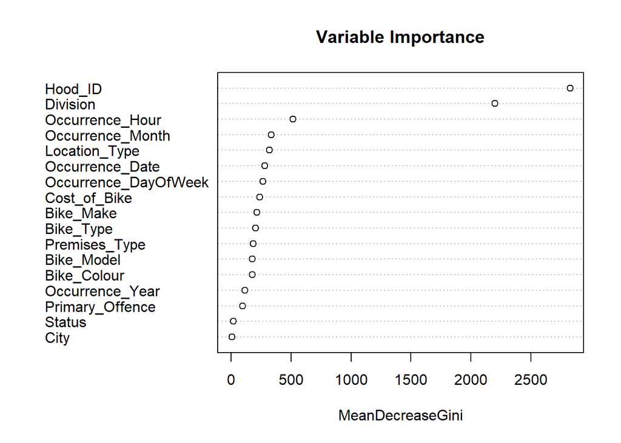

```r
varImpPlot(rf_model_09, sort = TRUE, main = "Variable Importance")
```

```r
importance(rf_model_09)
```

```
##                      MeanDecreaseGini
## Primary_Offence             93.926559
## Occurrence_Date            280.076074
## Occurrence_Year            113.569613
## Occurrence_Month           334.806570
## Occurrence_DayOfWeek       264.284278
## Occurrence_Hour            515.539632
## Division                  2202.484117
## City                         4.243066
## Hood_ID                   2827.832339
## Location_Type              318.088666
## Premises_Type              181.658901
## Bike_Make                  216.098003
## Bike_Model                 174.964342
## Bike_Type                  200.992538
## Bike_Colour                174.673031
## Cost_of_Bike               238.199864
## Status                      16.962487
```

No NeighbourhoodName and No Division Variables were used

```r
set.seed(999)
data_1<- bt_clean_future_selection

#Random Sampling
Index<- sample(nrow(data_1), floor(0.70*nrow(data_1)))
data_1_train<- data_1[Index,]
data_1_test<- data_1[-Index,]

#Treating train data
data_1_train$Cost_of_Bike[is.na(data_1_train$Cost_of_Bike)]<- mean(data_1_train$Cost_of_Bike,na.rm=TRUE)
data_1_train$Occurrence_Year[data_1_train$Occurrence_Year==2009] <- 2014
data_1_train$Occurrence_Year[data_1_train$Occurrence_Year==2010] <- 2014
data_1_train$Occurrence_Year[data_1_train$Occurrence_Year==2011] <- 2014
data_1_train$Occurrence_Year[data_1_train$Occurrence_Year==2012] <- 2014
data_1_train$Occurrence_Year[data_1_train$Occurrence_Year==2013] <- 2014

ctrl<- trainControl(method = "repeatedcv", number = 10 ,repeats = 10)

#Building model
rf_model_10<- randomForest(Hood_Risk~.-NeighbourhoodName-Division, data = data_1_train, ntree = 100, trainControl = ctrl, tuneLength = 50)
print(rf_model_10)
```

```
##
## Call:
##  randomForest(formula = Hood_Risk ~ . - NeighbourhoodName - Division,      data = data_1_train, ntree = 100, trainControl = ctrl, tuneLength = 50)
##                Type of random forest: classification
##                      Number of trees: 100
## No. of variables tried at each split: 4
##
##         OOB estimate of  error rate: 13.06%
## Confusion matrix:
##           Very Low Low Medium High Very High class.error
## Very Low        27  22    154   78        39   0.9156250
## Low              0 170    225  245        42   0.7507331
## Medium           1  41   1015  292       117   0.3076398
## High             1  23    190 1704       673   0.3423389
## Very High        0   4     69  122     12644   0.0151881
```

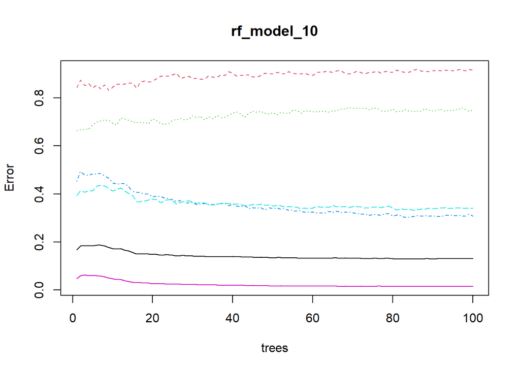

```r
plot(rf_model_10)
```

```r
#Testing Model
risk_pred_rf_model_10<- predict(rf_model_10, data_1_test)


#Statistics about model
data_1_test$risk_pred_rf_model_10<- risk_pred_rf_model_10
conf_matrix_rf_model_10<- table(data_1_test$Hood_Risk, data_1_test$risk_pred_rf_model_10)
conf_matrix_rf_model_10
```

```
##
##             Very Low  Low Medium High Very High
##   Very Low         3    3     63   23        14
##   Low              1   38    127  100        11
##   Medium           0    5    413   92        45
##   High             0    5     78  613       286
##   Very High        0    1     28   46      5162
```

```r
class_accuarcy_rf_model_10<- sum(diag(conf_matrix_rf_model_10)/sum(conf_matrix_rf_model_10))
class_accuarcy_rf_model_10
```

```
## [1] 0.8703367
```

```r
confusionMatrix(conf_matrix_rf_model_10)
```

```
## Confusion Matrix and Statistics
##
##
##             Very Low  Low Medium High Very High
##   Very Low         3    3     63   23        14
##   Low              1   38    127  100        11
##   Medium           0    5    413   92        45
##   High             0    5     78  613       286
##   Very High        0    1     28   46      5162
##
## Overall Statistics
##
##                Accuracy : 0.8703
##                  95% CI : (0.8623, 0.878)
##     No Information Rate : 0.771
##     P-Value [Acc > NIR] : < 2.2e-16
##
##                   Kappa : 0.6846
##
##  Mcnemar's Test P-Value : < 2.2e-16
##
## Statistics by Class:
##
##                      Class: Very Low Class: Low Class: Medium Class: High
## Sensitivity                0.7500000   0.730769       0.58251     0.70137
## Specificity                0.9856004   0.966362       0.97798     0.94127
## Pos Pred Value             0.0283019   0.137184       0.74414     0.62424
## Neg Pred Value             0.9998582   0.997965       0.95517     0.95773
## Prevalence                 0.0005589   0.007266       0.09906     0.12212
## Detection Rate             0.0004192   0.005309       0.05771     0.08565
## Detection Prevalence       0.0148107   0.038703       0.07755     0.13721
## Balanced Accuracy          0.8678002   0.848565       0.78024     0.82132
##                      Class: Very High
## Sensitivity                    0.9355
## Specificity                    0.9542
## Pos Pred Value                 0.9857
## Neg Pred Value                 0.8146
## Prevalence                     0.7710
## Detection Rate                 0.7213
## Detection Prevalence           0.7317
## Balanced Accuracy              0.9449
```

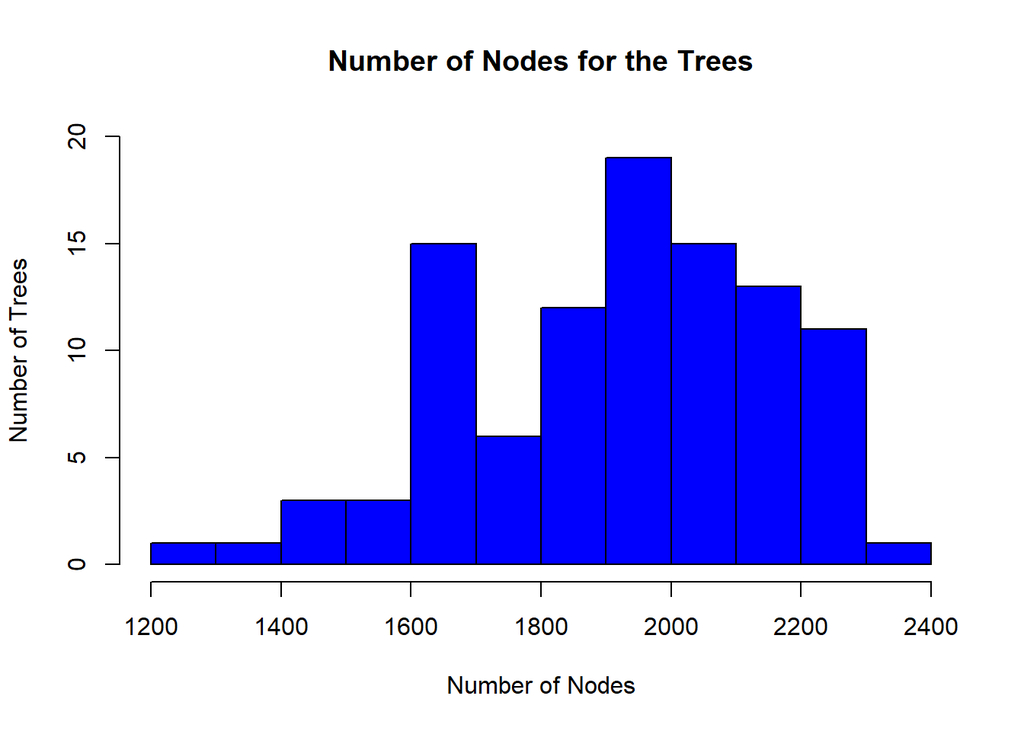

```r
hist(treesize(rf_model_10),ylim = c(0, 20) ,xlab = "Number of Nodes", ylab = "Number of Trees", main = "Number of Nodes for the Trees", col = "blue")
```

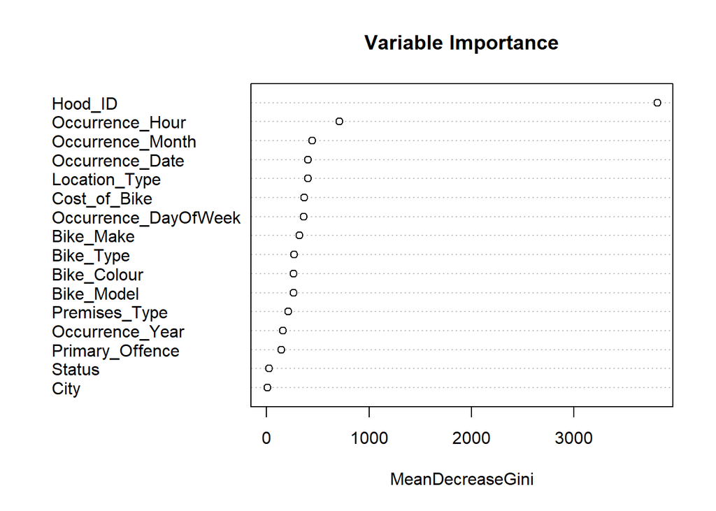

```r
varImpPlot(rf_model_10, sort = TRUE, main = "Variable Importance")
```

```r
importance(rf_model_10)
```

```
##                      MeanDecreaseGini
## Primary_Offence             144.26177
## Occurrence_Date             404.37190
## Occurrence_Year             160.28045
## Occurrence_Month            445.52291
## Occurrence_DayOfWeek        360.13274
## Occurrence_Hour             708.31076
## City                          6.75370
## Hood_ID                    3811.28476
## Location_Type               403.63268
## Premises_Type               209.08110
## Bike_Make                   320.63939
## Bike_Model                  261.35497
## Bike_Type                   270.16198
## Bike_Colour                 264.31609
## Cost_of_Bike                366.81125
## Status                       23.80296
```

No NeighbourhoodName and No Division Hood_ID were used

```r
set.seed(999)
data_1<- bt_clean_future_selection

#Random Sampling
Index<- sample(nrow(data_1), floor(0.70*nrow(data_1)))
data_1_train<- data_1[Index,]
data_1_test<- data_1[-Index,]

#Treating train data
data_1_train$Cost_of_Bike[is.na(data_1_train$Cost_of_Bike)]<- mean(data_1_train$Cost_of_Bike,na.rm=TRUE)
data_1_train$Occurrence_Year[data_1_train$Occurrence_Year==2009] <- 2014
data_1_train$Occurrence_Year[data_1_train$Occurrence_Year==2010] <- 2014
data_1_train$Occurrence_Year[data_1_train$Occurrence_Year==2011] <- 2014
data_1_train$Occurrence_Year[data_1_train$Occurrence_Year==2012] <- 2014
data_1_train$Occurrence_Year[data_1_train$Occurrence_Year==2013] <- 2014

ctrl<- trainControl(method = "repeatedcv", number = 10 ,repeats = 10)

#Building model
rf_model_11<- randomForest(Hood_Risk~.-Hood_ID-NeighbourhoodName-Division, data = data_1_train, ntree = 100, trainControl = ctrl, tuneLength = 50)
print(rf_model_11)
```

```
##
## Call:
##  randomForest(formula = Hood_Risk ~ . - Hood_ID - NeighbourhoodName -      Division, data = data_1_train, ntree = 100, trainControl = ctrl,      tuneLength = 50)
##                Type of random forest: classification
##                      Number of trees: 100
## No. of variables tried at each split: 3
##
##         OOB estimate of  error rate: 26.07%
## Confusion matrix:
##           Very Low Low Medium High Very High class.error
## Very Low        11   2     15   20       272  0.96562500
## Low              1  70     21   42       548  0.89736070
## Medium           0   4    175   92      1195  0.88062756
## High             1   3     36  426      2125  0.83558472
## Very High        1   4     50  234     12550  0.02250954
```

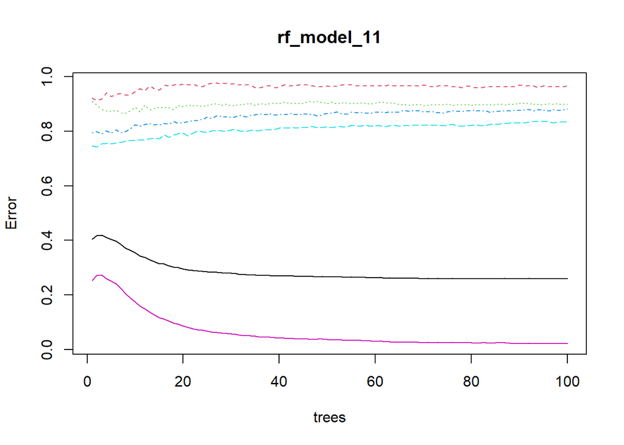

```r
plot(rf_model_11)
```

```r
#Testing Model
risk_pred_rf_model_11<- predict(rf_model_11, data_1_test)


#Statistics about model
data_1_test$risk_pred_rf_model_11<- risk_pred_rf_model_11
conf_matrix_rf_model_11<- table(data_1_test$Hood_Risk, data_1_test$risk_pred_rf_model_11)
conf_matrix_rf_model_11
```

```
##
##             Very Low  Low Medium High Very High
##   Very Low         0    0      6    9        91
##   Low              0    6      5    9       257
##   Medium           0    0     41   17       497
##   High             0    0     11   60       911
##   Very High        0    1     13   32      5191
```

```r
class_accuarcy_rf_model_11<- sum(diag(conf_matrix_rf_model_11)/sum(conf_matrix_rf_model_11))
class_accuarcy_rf_model_11
```

```
## [1] 0.7402543
```

```r
confusionMatrix(conf_matrix_rf_model_11)
```

```
## Confusion Matrix and Statistics
##
##
##             Very Low  Low Medium High Very High
##   Very Low         0    0      6    9        91
##   Low              0    6      5    9       257
##   Medium           0    0     41   17       497
##   High             0    0     11   60       911
##   Very High        0    1     13   32      5191
##
## Overall Statistics
##
##                Accuracy : 0.7403
##                  95% CI : (0.7299, 0.7504)
##     No Information Rate : 0.9707
##     P-Value [Acc > NIR] : 1
##
##                   Kappa : 0.0932
##
##  Mcnemar's Test P-Value : NA
##
## Statistics by Class:
##
##                      Class: Very Low Class: Low Class: Medium Class: High
## Sensitivity                       NA  0.8571429      0.539474    0.472441
## Specificity                  0.98519  0.9620979      0.927411    0.868848
## Pos Pred Value                    NA  0.0216606      0.073874    0.061100
## Neg Pred Value                    NA  0.9998547      0.994699    0.989150
## Prevalence                   0.00000  0.0009781      0.010619    0.017745
## Detection Rate               0.00000  0.0008383      0.005729    0.008383
## Detection Prevalence         0.01481  0.0387034      0.077546    0.137208
## Balanced Accuracy                 NA  0.9096204      0.733443    0.670644
##                      Class: Very High
## Sensitivity                   0.74723
## Specificity                   0.78095
## Pos Pred Value                0.99122
## Neg Pred Value                0.08542
## Prevalence                    0.97066
## Detection Rate                0.72530
## Detection Prevalence          0.73173
## Balanced Accuracy             0.76409
```

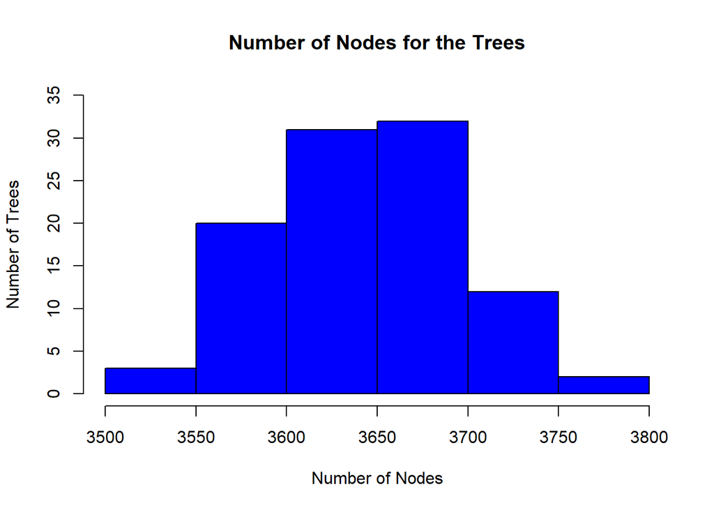

```r
hist(treesize(rf_model_11),ylim = c(0, 35) ,xlab = "Number of Nodes", ylab = "Number of Trees", main = "Number of Nodes for the Trees", col = "blue")
```

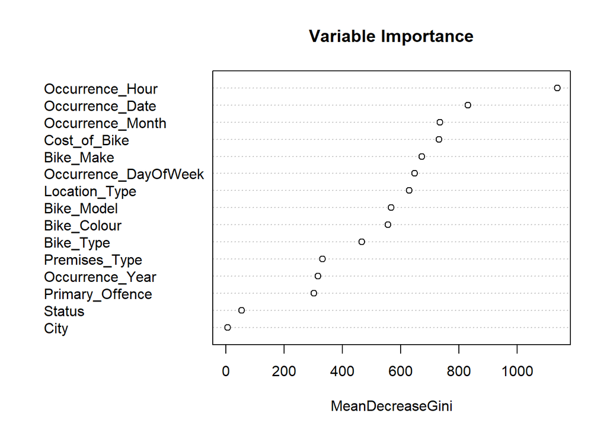

```r
varImpPlot(rf_model_11, sort = TRUE, main = "Variable Importance")
```

```r
importance(rf_model_11)
```

```
##                      MeanDecreaseGini
## Primary_Offence            302.250725
## Occurrence_Date            831.260424
## Occurrence_Year            315.419098
## Occurrence_Month           735.280567
## Occurrence_DayOfWeek       647.603629
## Occurrence_Hour           1137.081233
## City                         6.260186
## Location_Type              629.528010
## Premises_Type              330.781590
## Bike_Make                  672.911938
## Bike_Model                 566.406465
## Bike_Type                  466.035155
## Bike_Colour                556.553743
## Cost_of_Bike               731.373014
## Status                      54.318136
```

```r
n_conf_matrix_rf_model_11 = sum(conf_matrix_rf_model_11)
nc_conf_matrix_rf_model_11 = nrow(conf_matrix_rf_model_11)
diag_conf_matrix_rf_model_11 = diag(conf_matrix_rf_model_11)
rowsums_conf_matrix_rf_model_11 = apply(conf_matrix_rf_model_11, 1, sum)
colsums_conf_matrix_rf_model_11 = apply(conf_matrix_rf_model_11, 2, sum)

precision_conf_matrix_rf_model_11 = diag_conf_matrix_rf_model_11 / colsums_conf_matrix_rf_model_11
recall_conf_matrix_rf_model_11 = diag_conf_matrix_rf_model_11 / rowsums_conf_matrix_rf_model_11
f1_conf_matrix_rf_model_11 = 2 * precision_conf_matrix_rf_model_11 * recall_conf_matrix_rf_model_11 / (precision_conf_matrix_rf_model_11 + recall_conf_matrix_rf_model_11)
data_frame_conf_matrix_rf_model_11<- data.frame(precision_conf_matrix_rf_model_11, recall_conf_matrix_rf_model_11, f1_conf_matrix_rf_model_11)
data_frame_conf_matrix_rf_model_11
```

```
##           precision_conf_matrix_rf_model_11 recall_conf_matrix_rf_model_11
## Very Low                                NaN                     0.00000000
## Low                               0.8571429                     0.02166065
## Medium                            0.5394737                     0.07387387
## High                              0.4724409                     0.06109980
## Very High                         0.7472290                     0.99121635
##           f1_conf_matrix_rf_model_11
## Very Low                         NaN
## Low                       0.04225352
## Medium                    0.12995246
## High                      0.10820559
## Very High                 0.85210112
```

Comparing models according accuracy

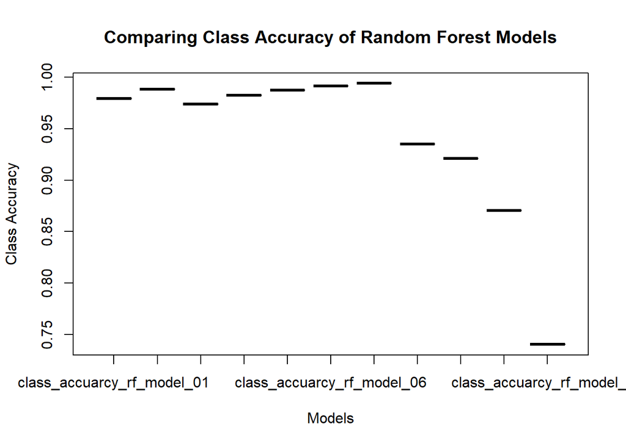

```r
class_rf_models<- data.frame(class_accuarcy_rf_model_01, class_accuarcy_rf_model_02, class_accuarcy_rf_model_03, class_accuarcy_rf_model_04, class_accuarcy_rf_model_05, class_accuarcy_rf_model_06, class_accuarcy_rf_model_07, class_accuarcy_rf_model_08, class_accuarcy_rf_model_09, class_accuarcy_rf_model_10, class_accuarcy_rf_model_11)
boxplot(class_rf_models, xlab = "Models", ylab = "Class Accuracy", main = "Comparing Class Accuracy of Random Forest Models")
```

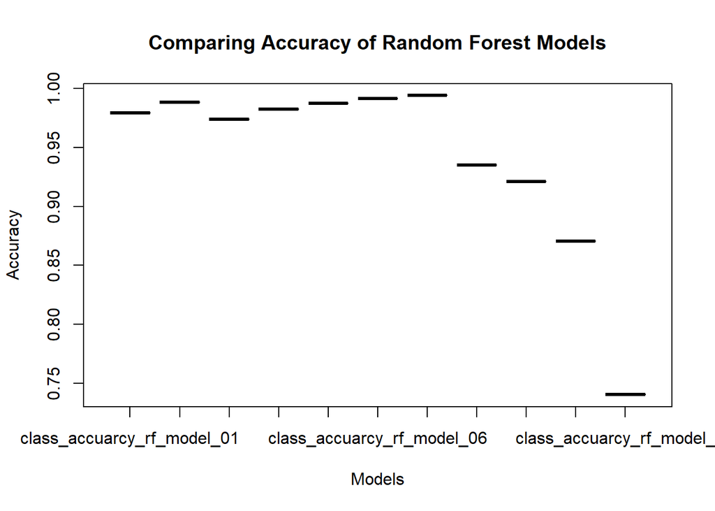

```r
boxplot(class_rf_models, xlab = "Models", ylab = "Accuracy", main = "Comparing Accuracy of Random Forest Models")
```

__________________________________________Decision Tree model_____________________________________________________

Based on the variable importance of Random Forest model we use features to build our Tree model on different features

All Variables used

```r
#Building model
set.seed(999)
data_1<- bt_clean_future_selection

#Random Sampling
Index<- sample(nrow(data_1), floor(0.70*nrow(data_1)))
data_1_train<- data_1[Index,]
data_1_test<- data_1[-Index,]

#Treating train data
data_1_train$Cost_of_Bike[is.na(data_1_train$Cost_of_Bike)]<- mean(data_1_train$Cost_of_Bike,na.rm=TRUE)
data_1_train$Occurrence_Year[data_1_train$Occurrence_Year==2009] <- 2014
data_1_train$Occurrence_Year[data_1_train$Occurrence_Year==2010] <- 2014
data_1_train$Occurrence_Year[data_1_train$Occurrence_Year==2011] <- 2014
data_1_train$Occurrence_Year[data_1_train$Occurrence_Year==2012] <- 2014
data_1_train$Occurrence_Year[data_1_train$Occurrence_Year==2013] <- 2014

ctrl<- trainControl(method = "repeatedcv", number = 10 ,repeats = 10)

tree_model_01 <- train(Hood_Risk ~ Hood_ID + Division + NeighbourhoodName + Occurrence_Hour + Location_Type+Occurrence_Month + Occurrence_Date + Occurrence_DayOfWeek + Premises_Type, data = data_1_train, method = "rpart", trControl = ctrl, tuneLength = 50)

print(tree_model_01)
```

```
## CART
##
## 17898 samples
##     9 predictor
##     5 classes: 'Very Low', 'Low', 'Medium', 'High', 'Very High'
##
## No pre-processing
## Resampling: Cross-Validated (10 fold, repeated 10 times)
## Summary of sample sizes: 16109, 16109, 16109, 16108, 16109, 16107, ...
## Resampling results across tuning parameters:
##
##   cp           Accuracy   Kappa
##   0.000000000  0.9985697  0.9968623
##   0.003727445  0.9797797  0.9555400
##   0.007454889  0.9456591  0.8794795
##   0.011182334  0.9290480  0.8429027
##   0.014909779  0.9124538  0.8049759
##   0.018637224  0.8775853  0.7180461
##   0.022364668  0.8541343  0.6506828
##   0.026092113  0.8541343  0.6506828
##   0.029819558  0.8509832  0.6404743
##   0.033547003  0.8497038  0.6359522
##   0.037274447  0.8396969  0.6108611
##   0.041001892  0.8395907  0.6105922
##   0.044729337  0.8395907  0.6105922
##   0.048456781  0.8008329  0.5200324
##   0.052184226  0.7908040  0.5020310
##   0.055911671  0.7716281  0.4700723
##   0.059639116  0.7689687  0.4657065
##   0.063366560  0.7689687  0.4657065
##   0.067094005  0.7689687  0.4657065
##   0.070821450  0.7689687  0.4657065
##   0.074548894  0.7689687  0.4657065
##   0.078276339  0.7689687  0.4657065
##   0.082003784  0.7689687  0.4657065
##   0.085731229  0.7689687  0.4657065
##   0.089458673  0.7689687  0.4657065
##   0.093186118  0.7689687  0.4657065
##   0.096913563  0.7689687  0.4657065
##   0.100641008  0.7689687  0.4657065
```

[output cut: 10 more lines]

```
##   0.141642900  0.7689687  0.4657065
##   0.145370344  0.7689687  0.4657065
##   0.149097789  0.7689687  0.4657065
##   0.152825234  0.7689687  0.4657065
##   0.156552678  0.7689687  0.4657065
##   0.160280123  0.7689687  0.4657065
##   0.164007568  0.7689687  0.4657065
##   0.167735013  0.7689687  0.4657065
##   0.171462457  0.7689687  0.4657065
##   0.175189902  0.7689687  0.4657065
##   0.178917347  0.7657955  0.4411446
##   0.182644791  0.7401503  0.2228978
##
## Accuracy was used to select the optimal model using the largest value.
## The final value used for the model was cp = 0.
```

```r
plot(tree_model_01)
```

[output not shown]

```r
#Testing Model
risk_pred_tree_model_01<- predict(tree_model_01, data_1_test)


#Statistics about model
data_1_test$risk_pred_tree_model_01<- risk_pred_tree_model_01
conf_matrix_tree_model_01<- table(data_1_test$Hood_Risk, data_1_test$risk_pred_tree_model_01)
conf_matrix_tree_model_01
```

```
##
##             Very Low  Low Medium High Very High
##   Very Low       109    0     11    4         0
##   Low              0  314      0    1         0
##   Medium           0    0    623    0         0
##   High             0    0      0 1076         0
##   Very High        0    0      0    1      5532
```

```r
class_accuarcy_tree_model_01<- sum(diag(conf_matrix_tree_model_01)/sum(conf_matrix_tree_model_01))
class_accuarcy_tree_model_01
```

```
## [1] 0.9977839
```

```r
confusionMatrix(conf_matrix_tree_model_01)
```

```
## Confusion Matrix and Statistics
##
##
##             Very Low  Low Medium High Very High
##   Very Low       109    0     11    4         0
##   Low              0  314      0    1         0
##   Medium           0    0    623    0         0
##   High             0    0      0 1076         0
##   Very High        0    0      0    1      5532
##
## Overall Statistics
##
##                Accuracy : 0.9978
##                  95% CI : (0.9965, 0.9987)
##     No Information Rate : 0.7212
##     P-Value [Acc > NIR] : < 2.2e-16
##
##                   Kappa : 0.9951
##
##  Mcnemar's Test P-Value : NA
##
## Statistics by Class:
##
##                      Class: Very Low Class: Low Class: Medium Class: High
## Sensitivity                  1.00000    1.00000       0.98265      0.9945
## Specificity                  0.99802    0.99986       1.00000      1.0000
## Pos Pred Value               0.87903    0.99683       1.00000      1.0000
## Neg Pred Value               1.00000    1.00000       0.99844      0.9991
## Prevalence                   0.01421    0.04093       0.08265      0.1411
## Detection Rate               0.01421    0.04093       0.08121      0.1403
## Detection Prevalence         0.01616    0.04106       0.08121      0.1403
## Balanced Accuracy            0.99901    0.99993       0.99132      0.9972
##                      Class: Very High
## Sensitivity                    1.0000
## Specificity                    0.9995
## Pos Pred Value                 0.9998
## Neg Pred Value                 1.0000
## Prevalence                     0.7212
## Detection Rate                 0.7212
## Detection Prevalence           0.7213
## Balanced Accuracy              0.9998
```

```r
n_conf_matrix_tree_model_01 = sum(conf_matrix_tree_model_01)
nc_conf_matrix_tree_model_01 = nrow(conf_matrix_tree_model_01)
diag_conf_matrix_tree_model_01 = diag(conf_matrix_tree_model_01)
rowsums_conf_matrix_tree_model_01 = apply(conf_matrix_tree_model_01, 1, sum)
colsums_conf_matrix_tree_model_01 = apply(conf_matrix_tree_model_01, 2, sum)

precision_conf_matrix_tree_model_01 = diag_conf_matrix_tree_model_01 / colsums_conf_matrix_tree_model_01
recall_conf_matrix_tree_model_01 = diag_conf_matrix_tree_model_01 / rowsums_conf_matrix_tree_model_01
f1_conf_matrix_tree_model_01 = 2 * precision_conf_matrix_tree_model_01 * recall_conf_matrix_tree_model_01 / (precision_conf_matrix_tree_model_01 + recall_conf_matrix_tree_model_01)
data_frame_conf_matrix_tree_model_01<- data.frame(precision_conf_matrix_tree_model_01, recall_conf_matrix_tree_model_01, f1_conf_matrix_tree_model_01)
data_frame_conf_matrix_tree_model_01
```

```
##           precision_conf_matrix_tree_model_01 recall_conf_matrix_tree_model_01
## Very Low                            1.0000000                        0.8790323
## Low                                 1.0000000                        0.9968254
## Medium                              0.9826498                        1.0000000
## High                                0.9944547                        1.0000000
## Very High                           1.0000000                        0.9998193
##           f1_conf_matrix_tree_model_01
## Very Low                     0.9356223
## Low                          0.9984102
## Medium                       0.9912490
## High                         0.9972196
## Very High                    0.9999096
```

No Premises_Type Variables were used

```r
set.seed(999)
data_1<- bt_clean_future_selection

#Random Sampling
Index<- sample(nrow(data_1), floor(0.70*nrow(data_1)))
data_1_train<- data_1[Index,]
data_1_test<- data_1[-Index,]

#Treating train data
data_1_train$Cost_of_Bike[is.na(data_1_train$Cost_of_Bike)]<- mean(data_1_train$Cost_of_Bike,na.rm=TRUE)
data_1_train$Occurrence_Year[data_1_train$Occurrence_Year==2009] <- 2014
data_1_train$Occurrence_Year[data_1_train$Occurrence_Year==2010] <- 2014
data_1_train$Occurrence_Year[data_1_train$Occurrence_Year==2011] <- 2014
data_1_train$Occurrence_Year[data_1_train$Occurrence_Year==2012] <- 2014
data_1_train$Occurrence_Year[data_1_train$Occurrence_Year==2013] <- 2014

ctrl<- trainControl(method = "repeatedcv", number = 10 ,repeats = 10)

tree_model_02 <- train(Hood_Risk ~ Hood_ID + Division + NeighbourhoodName + Occurrence_Hour + Location_Type+Occurrence_Month + Occurrence_Date + Occurrence_DayOfWeek, data = data_1_train, method = "rpart", trControl = ctrl, tuneLength = 50)

print(tree_model_02)
```

```
## CART
##
## 17898 samples
##     8 predictor
##     5 classes: 'Very Low', 'Low', 'Medium', 'High', 'Very High'
##
## No pre-processing
## Resampling: Cross-Validated (10 fold, repeated 10 times)
## Summary of sample sizes: 16109, 16109, 16109, 16108, 16109, 16107, ...
## Resampling results across tuning parameters:
##
##   cp           Accuracy   Kappa
##   0.000000000  0.9985697  0.9968623
##   0.003727445  0.9797797  0.9555400
##   0.007454889  0.9456591  0.8794795
##   0.011182334  0.9290480  0.8429027
##   0.014909779  0.9124538  0.8049759
##   0.018637224  0.8775853  0.7180461
##   0.022364668  0.8541343  0.6506828
##   0.026092113  0.8541343  0.6506828
##   0.029819558  0.8509832  0.6404743
##   0.033547003  0.8497038  0.6359522
##   0.037274447  0.8396969  0.6108611
##   0.041001892  0.8395907  0.6105922
##   0.044729337  0.8395907  0.6105922
##   0.048456781  0.8008329  0.5200324
##   0.052184226  0.7908040  0.5020310
##   0.055911671  0.7716281  0.4700723
##   0.059639116  0.7689687  0.4657065
##   0.063366560  0.7689687  0.4657065
##   0.067094005  0.7689687  0.4657065
##   0.070821450  0.7689687  0.4657065
##   0.074548894  0.7689687  0.4657065
##   0.078276339  0.7689687  0.4657065
##   0.082003784  0.7689687  0.4657065
##   0.085731229  0.7689687  0.4657065
##   0.089458673  0.7689687  0.4657065
##   0.093186118  0.7689687  0.4657065
##   0.096913563  0.7689687  0.4657065
##   0.100641008  0.7689687  0.4657065
```

[output cut: 10 more lines]

```
##   0.141642900  0.7689687  0.4657065
##   0.145370344  0.7689687  0.4657065
##   0.149097789  0.7689687  0.4657065
##   0.152825234  0.7689687  0.4657065
##   0.156552678  0.7689687  0.4657065
##   0.160280123  0.7689687  0.4657065
##   0.164007568  0.7689687  0.4657065
##   0.167735013  0.7689687  0.4657065
##   0.171462457  0.7689687  0.4657065
##   0.175189902  0.7689687  0.4657065
##   0.178917347  0.7657955  0.4411446
##   0.182644791  0.7401503  0.2228978
##
## Accuracy was used to select the optimal model using the largest value.
## The final value used for the model was cp = 0.
```

```r
plot(tree_model_02)
```

[output not shown]

```r
#Testing Model
risk_pred_tree_model_02<- predict(tree_model_02, data_1_test)


#Statistics about model
data_1_test$risk_pred_tree_model_02<- risk_pred_tree_model_02
conf_matrix_tree_model_02<- table(data_1_test$Hood_Risk, data_1_test$risk_pred_tree_model_02)
conf_matrix_tree_model_02
```

```
##
##             Very Low  Low Medium High Very High
##   Very Low       109    0     11    4         0
##   Low              0  314      0    1         0
##   Medium           0    0    623    0         0
##   High             0    0      0 1076         0
##   Very High        0    0      0    1      5532
```

```r
class_accuarcy_tree_model_02<- sum(diag(conf_matrix_tree_model_02)/sum(conf_matrix_tree_model_02))
class_accuarcy_tree_model_02
```

```
## [1] 0.9977839
```

```r
confusionMatrix(conf_matrix_tree_model_02)
```

```
## Confusion Matrix and Statistics
##
##
##             Very Low  Low Medium High Very High
##   Very Low       109    0     11    4         0
##   Low              0  314      0    1         0
##   Medium           0    0    623    0         0
##   High             0    0      0 1076         0
##   Very High        0    0      0    1      5532
##
## Overall Statistics
##
##                Accuracy : 0.9978
##                  95% CI : (0.9965, 0.9987)
##     No Information Rate : 0.7212
##     P-Value [Acc > NIR] : < 2.2e-16
##
##                   Kappa : 0.9951
##
##  Mcnemar's Test P-Value : NA
##
## Statistics by Class:
##
##                      Class: Very Low Class: Low Class: Medium Class: High
## Sensitivity                  1.00000    1.00000       0.98265      0.9945
## Specificity                  0.99802    0.99986       1.00000      1.0000
## Pos Pred Value               0.87903    0.99683       1.00000      1.0000
## Neg Pred Value               1.00000    1.00000       0.99844      0.9991
## Prevalence                   0.01421    0.04093       0.08265      0.1411
## Detection Rate               0.01421    0.04093       0.08121      0.1403
## Detection Prevalence         0.01616    0.04106       0.08121      0.1403
## Balanced Accuracy            0.99901    0.99993       0.99132      0.9972
##                      Class: Very High
## Sensitivity                    1.0000
## Specificity                    0.9995
## Pos Pred Value                 0.9998
## Neg Pred Value                 1.0000
## Prevalence                     0.7212
## Detection Rate                 0.7212
## Detection Prevalence           0.7213
## Balanced Accuracy              0.9998
```

No Premises_Type+Occurrence_DayOfWeek Variables were used

```r
set.seed(999)
data_1<- bt_clean_future_selection

#Random Sampling
Index<- sample(nrow(data_1), floor(0.70*nrow(data_1)))
data_1_train<- data_1[Index,]
data_1_test<- data_1[-Index,]

#Treating train data
data_1_train$Cost_of_Bike[is.na(data_1_train$Cost_of_Bike)]<- mean(data_1_train$Cost_of_Bike,na.rm=TRUE)
data_1_train$Occurrence_Year[data_1_train$Occurrence_Year==2009] <- 2014
data_1_train$Occurrence_Year[data_1_train$Occurrence_Year==2010] <- 2014
data_1_train$Occurrence_Year[data_1_train$Occurrence_Year==2011] <- 2014
data_1_train$Occurrence_Year[data_1_train$Occurrence_Year==2012] <- 2014
data_1_train$Occurrence_Year[data_1_train$Occurrence_Year==2013] <- 2014

ctrl<- trainControl(method = "repeatedcv", number = 10 ,repeats = 10)

tree_model_03 <- train(Hood_Risk ~ Hood_ID + Division + NeighbourhoodName + Occurrence_Hour + Location_Type+Occurrence_Month + Occurrence_Date, data = data_1_train, method = "rpart", trControl = ctrl, tuneLength = 50)

print(tree_model_03)
```

```
## CART
##
## 17898 samples
##     7 predictor
##     5 classes: 'Very Low', 'Low', 'Medium', 'High', 'Very High'
##
## No pre-processing
## Resampling: Cross-Validated (10 fold, repeated 10 times)
## Summary of sample sizes: 16109, 16109, 16109, 16108, 16109, 16107, ...
## Resampling results across tuning parameters:
##
##   cp           Accuracy   Kappa
##   0.000000000  0.9985697  0.9968623
##   0.003727445  0.9797797  0.9555400
##   0.007454889  0.9456591  0.8794795
##   0.011182334  0.9290480  0.8429027
##   0.014909779  0.9124538  0.8049759
##   0.018637224  0.8775853  0.7180461
##   0.022364668  0.8541343  0.6506828
##   0.026092113  0.8541343  0.6506828
##   0.029819558  0.8509832  0.6404743
##   0.033547003  0.8497038  0.6359522
##   0.037274447  0.8396969  0.6108611
##   0.041001892  0.8395907  0.6105922
##   0.044729337  0.8395907  0.6105922
##   0.048456781  0.8008329  0.5200324
##   0.052184226  0.7908040  0.5020310
##   0.055911671  0.7716281  0.4700723
##   0.059639116  0.7689687  0.4657065
##   0.063366560  0.7689687  0.4657065
##   0.067094005  0.7689687  0.4657065
##   0.070821450  0.7689687  0.4657065
##   0.074548894  0.7689687  0.4657065
##   0.078276339  0.7689687  0.4657065
##   0.082003784  0.7689687  0.4657065
##   0.085731229  0.7689687  0.4657065
##   0.089458673  0.7689687  0.4657065
##   0.093186118  0.7689687  0.4657065
##   0.096913563  0.7689687  0.4657065
##   0.100641008  0.7689687  0.4657065
```

[output cut: 10 more lines]

```
##   0.141642900  0.7689687  0.4657065
##   0.145370344  0.7689687  0.4657065
##   0.149097789  0.7689687  0.4657065
##   0.152825234  0.7689687  0.4657065
##   0.156552678  0.7689687  0.4657065
##   0.160280123  0.7689687  0.4657065
##   0.164007568  0.7689687  0.4657065
##   0.167735013  0.7689687  0.4657065
##   0.171462457  0.7689687  0.4657065
##   0.175189902  0.7689687  0.4657065
##   0.178917347  0.7657955  0.4411446
##   0.182644791  0.7401503  0.2228978
##
## Accuracy was used to select the optimal model using the largest value.
## The final value used for the model was cp = 0.
```

```r
plot(tree_model_03)
```

[output not shown]

```r
#Testing Model
risk_pred_tree_model_03<- predict(tree_model_03, data_1_test)


#Statistics about model
data_1_test$risk_pred_tree_model_03<- risk_pred_tree_model_03
conf_matrix_tree_model_03<- table(data_1_test$Hood_Risk, data_1_test$risk_pred_tree_model_03)
conf_matrix_tree_model_03
```

```
##
##             Very Low  Low Medium High Very High
##   Very Low       109    0     11    4         0
##   Low              0  314      0    1         0
##   Medium           0    0    623    0         0
##   High             0    0      0 1076         0
##   Very High        0    0      0    1      5532
```

```r
class_accuarcy_tree_model_03<- sum(diag(conf_matrix_tree_model_03)/sum(conf_matrix_tree_model_03))
class_accuarcy_tree_model_03
```

```
## [1] 0.9977839
```

```r
confusionMatrix(conf_matrix_tree_model_03)
```

```
## Confusion Matrix and Statistics
##
##
##             Very Low  Low Medium High Very High
##   Very Low       109    0     11    4         0
##   Low              0  314      0    1         0
##   Medium           0    0    623    0         0
##   High             0    0      0 1076         0
##   Very High        0    0      0    1      5532
##
## Overall Statistics
##
##                Accuracy : 0.9978
##                  95% CI : (0.9965, 0.9987)
##     No Information Rate : 0.7212
##     P-Value [Acc > NIR] : < 2.2e-16
##
##                   Kappa : 0.9951
##
##  Mcnemar's Test P-Value : NA
##
## Statistics by Class:
##
##                      Class: Very Low Class: Low Class: Medium Class: High
## Sensitivity                  1.00000    1.00000       0.98265      0.9945
## Specificity                  0.99802    0.99986       1.00000      1.0000
## Pos Pred Value               0.87903    0.99683       1.00000      1.0000
## Neg Pred Value               1.00000    1.00000       0.99844      0.9991
## Prevalence                   0.01421    0.04093       0.08265      0.1411
## Detection Rate               0.01421    0.04093       0.08121      0.1403
## Detection Prevalence         0.01616    0.04106       0.08121      0.1403
## Balanced Accuracy            0.99901    0.99993       0.99132      0.9972
##                      Class: Very High
## Sensitivity                    1.0000
## Specificity                    0.9995
## Pos Pred Value                 0.9998
## Neg Pred Value                 1.0000
## Prevalence                     0.7212
## Detection Rate                 0.7212
## Detection Prevalence           0.7213
## Balanced Accuracy              0.9998
```

No Premises_Type+Occurrence_DayOfWeek+Occurrence_Date Variables were used

```r
set.seed(999)
data_1<- bt_clean_future_selection

#Random Sampling
Index<- sample(nrow(data_1), floor(0.70*nrow(data_1)))
data_1_train<- data_1[Index,]
data_1_test<- data_1[-Index,]

#Treating train data
data_1_train$Cost_of_Bike[is.na(data_1_train$Cost_of_Bike)]<- mean(data_1_train$Cost_of_Bike,na.rm=TRUE)
data_1_train$Occurrence_Year[data_1_train$Occurrence_Year==2009] <- 2014
data_1_train$Occurrence_Year[data_1_train$Occurrence_Year==2010] <- 2014
data_1_train$Occurrence_Year[data_1_train$Occurrence_Year==2011] <- 2014
data_1_train$Occurrence_Year[data_1_train$Occurrence_Year==2012] <- 2014
data_1_train$Occurrence_Year[data_1_train$Occurrence_Year==2013] <- 2014

ctrl<- trainControl(method = "repeatedcv", number = 10 ,repeats = 10)

tree_model_04 <- train(Hood_Risk ~ Hood_ID + Division + NeighbourhoodName + Occurrence_Hour + Location_Type+Occurrence_Month, data = data_1_train, method = "rpart", trControl = ctrl, tuneLength = 50)

print(tree_model_04)
```

```
## CART
##
## 17898 samples
##     6 predictor
##     5 classes: 'Very Low', 'Low', 'Medium', 'High', 'Very High'
##
## No pre-processing
## Resampling: Cross-Validated (10 fold, repeated 10 times)
## Summary of sample sizes: 16109, 16109, 16109, 16108, 16109, 16107, ...
## Resampling results across tuning parameters:
##
##   cp           Accuracy   Kappa
##   0.000000000  0.9985809  0.9968867
##   0.003727445  0.9797797  0.9555400
##   0.007454889  0.9456591  0.8794795
##   0.011182334  0.9290480  0.8429027
##   0.014909779  0.9124538  0.8049759
##   0.018637224  0.8775853  0.7180461
##   0.022364668  0.8541343  0.6506828
##   0.026092113  0.8541343  0.6506828
##   0.029819558  0.8509832  0.6404743
##   0.033547003  0.8497038  0.6359522
##   0.037274447  0.8396969  0.6108611
##   0.041001892  0.8395907  0.6105922
##   0.044729337  0.8395907  0.6105922
##   0.048456781  0.8008329  0.5200324
##   0.052184226  0.7908040  0.5020310
##   0.055911671  0.7716281  0.4700723
##   0.059639116  0.7689687  0.4657065
##   0.063366560  0.7689687  0.4657065
##   0.067094005  0.7689687  0.4657065
##   0.070821450  0.7689687  0.4657065
##   0.074548894  0.7689687  0.4657065
##   0.078276339  0.7689687  0.4657065
##   0.082003784  0.7689687  0.4657065
##   0.085731229  0.7689687  0.4657065
##   0.089458673  0.7689687  0.4657065
##   0.093186118  0.7689687  0.4657065
##   0.096913563  0.7689687  0.4657065
##   0.100641008  0.7689687  0.4657065
```

[output cut: 10 more lines]

```
##   0.141642900  0.7689687  0.4657065
##   0.145370344  0.7689687  0.4657065
##   0.149097789  0.7689687  0.4657065
##   0.152825234  0.7689687  0.4657065
##   0.156552678  0.7689687  0.4657065
##   0.160280123  0.7689687  0.4657065
##   0.164007568  0.7689687  0.4657065
##   0.167735013  0.7689687  0.4657065
##   0.171462457  0.7689687  0.4657065
##   0.175189902  0.7689687  0.4657065
##   0.178917347  0.7657955  0.4411446
##   0.182644791  0.7401503  0.2228978
##
## Accuracy was used to select the optimal model using the largest value.
## The final value used for the model was cp = 0.
```

```r
plot(tree_model_04)
```

[output not shown]

```r
#Testing Model
risk_pred_tree_model_04<- predict(tree_model_04, data_1_test)


#Statistics about model
data_1_test$risk_pred_tree_model_04<- risk_pred_tree_model_04
conf_matrix_tree_model_04<- table(data_1_test$Hood_Risk, data_1_test$risk_pred_tree_model_04)
conf_matrix_tree_model_04
```

```
##
##             Very Low  Low Medium High Very High
##   Very Low       109    0     11    4         0
##   Low              0  314      0    1         0
##   Medium           0    0    623    0         0
##   High             0    0      0 1076         0
##   Very High        0    0      0    1      5532
```

```r
class_accuarcy_tree_model_04<- sum(diag(conf_matrix_tree_model_04)/sum(conf_matrix_tree_model_04))
class_accuarcy_tree_model_04
```

```
## [1] 0.9977839
```

```r
confusionMatrix(conf_matrix_tree_model_04)
```

```
## Confusion Matrix and Statistics
##
##
##             Very Low  Low Medium High Very High
##   Very Low       109    0     11    4         0
##   Low              0  314      0    1         0
##   Medium           0    0    623    0         0
##   High             0    0      0 1076         0
##   Very High        0    0      0    1      5532
##
## Overall Statistics
##
##                Accuracy : 0.9978
##                  95% CI : (0.9965, 0.9987)
##     No Information Rate : 0.7212
##     P-Value [Acc > NIR] : < 2.2e-16
##
##                   Kappa : 0.9951
##
##  Mcnemar's Test P-Value : NA
##
## Statistics by Class:
##
##                      Class: Very Low Class: Low Class: Medium Class: High
## Sensitivity                  1.00000    1.00000       0.98265      0.9945
## Specificity                  0.99802    0.99986       1.00000      1.0000
## Pos Pred Value               0.87903    0.99683       1.00000      1.0000
## Neg Pred Value               1.00000    1.00000       0.99844      0.9991
## Prevalence                   0.01421    0.04093       0.08265      0.1411
## Detection Rate               0.01421    0.04093       0.08121      0.1403
## Detection Prevalence         0.01616    0.04106       0.08121      0.1403
## Balanced Accuracy            0.99901    0.99993       0.99132      0.9972
##                      Class: Very High
## Sensitivity                    1.0000
## Specificity                    0.9995
## Pos Pred Value                 0.9998
## Neg Pred Value                 1.0000
## Prevalence                     0.7212
## Detection Rate                 0.7212
## Detection Prevalence           0.7213
## Balanced Accuracy              0.9998
```

No Premises_Type+Occurrence_DayOfWeek+Occurrence_Date+Occurrence_Month Variables were used

```r
set.seed(999)
data_1<- bt_clean_future_selection

#Random Sampling
Index<- sample(nrow(data_1), floor(0.70*nrow(data_1)))
data_1_train<- data_1[Index,]
data_1_test<- data_1[-Index,]

#Treating train data
data_1_train$Cost_of_Bike[is.na(data_1_train$Cost_of_Bike)]<- mean(data_1_train$Cost_of_Bike,na.rm=TRUE)
data_1_train$Occurrence_Year[data_1_train$Occurrence_Year==2009] <- 2014
data_1_train$Occurrence_Year[data_1_train$Occurrence_Year==2010] <- 2014
data_1_train$Occurrence_Year[data_1_train$Occurrence_Year==2011] <- 2014
data_1_train$Occurrence_Year[data_1_train$Occurrence_Year==2012] <- 2014
data_1_train$Occurrence_Year[data_1_train$Occurrence_Year==2013] <- 2014

ctrl<- trainControl(method = "repeatedcv", number = 10 ,repeats = 10)

tree_model_05 <- train(Hood_Risk ~ Hood_ID + Division + NeighbourhoodName + Occurrence_Hour + Location_Type, data = data_1_train, method = "rpart", trControl = ctrl, tuneLength = 50)

print(tree_model_05)
```

```
## CART
##
## 17898 samples
##     5 predictor
##     5 classes: 'Very Low', 'Low', 'Medium', 'High', 'Very High'
##
## No pre-processing
## Resampling: Cross-Validated (10 fold, repeated 10 times)
## Summary of sample sizes: 16109, 16109, 16109, 16108, 16109, 16107, ...
## Resampling results across tuning parameters:
##
##   cp           Accuracy   Kappa
##   0.000000000  0.9985809  0.9968867
##   0.003727445  0.9797797  0.9555400
##   0.007454889  0.9456591  0.8794795
##   0.011182334  0.9290480  0.8429027
##   0.014909779  0.9124538  0.8049759
##   0.018637224  0.8775853  0.7180461
##   0.022364668  0.8541343  0.6506828
##   0.026092113  0.8541343  0.6506828
##   0.029819558  0.8509832  0.6404743
##   0.033547003  0.8497038  0.6359522
##   0.037274447  0.8396969  0.6108611
##   0.041001892  0.8395907  0.6105922
##   0.044729337  0.8395907  0.6105922
##   0.048456781  0.8008329  0.5200324
##   0.052184226  0.7908040  0.5020310
##   0.055911671  0.7716281  0.4700723
##   0.059639116  0.7689687  0.4657065
##   0.063366560  0.7689687  0.4657065
##   0.067094005  0.7689687  0.4657065
##   0.070821450  0.7689687  0.4657065
##   0.074548894  0.7689687  0.4657065
##   0.078276339  0.7689687  0.4657065
##   0.082003784  0.7689687  0.4657065
##   0.085731229  0.7689687  0.4657065
##   0.089458673  0.7689687  0.4657065
##   0.093186118  0.7689687  0.4657065
##   0.096913563  0.7689687  0.4657065
##   0.100641008  0.7689687  0.4657065
```

[output cut: 10 more lines]

```
##   0.141642900  0.7689687  0.4657065
##   0.145370344  0.7689687  0.4657065
##   0.149097789  0.7689687  0.4657065
##   0.152825234  0.7689687  0.4657065
##   0.156552678  0.7689687  0.4657065
##   0.160280123  0.7689687  0.4657065
##   0.164007568  0.7689687  0.4657065
##   0.167735013  0.7689687  0.4657065
##   0.171462457  0.7689687  0.4657065
##   0.175189902  0.7689687  0.4657065
##   0.178917347  0.7657955  0.4411446
##   0.182644791  0.7401503  0.2228978
##
## Accuracy was used to select the optimal model using the largest value.
## The final value used for the model was cp = 0.
```

```r
plot(tree_model_05)
```

[output not shown]

```r
#Testing Model
risk_pred_tree_model_05<- predict(tree_model_05, data_1_test)


#Statistics about model
data_1_test$risk_pred_tree_model_05<- risk_pred_tree_model_05
conf_matrix_tree_model_05<- table(data_1_test$Hood_Risk, data_1_test$risk_pred_tree_model_05)
conf_matrix_tree_model_05
```

```
##
##             Very Low  Low Medium High Very High
##   Very Low       109    0     11    4         0
##   Low              0  314      0    1         0
##   Medium           0    0    623    0         0
##   High             0    0      0 1076         0
##   Very High        0    0      0    1      5532
```

```r
class_accuarcy_tree_model_05<- sum(diag(conf_matrix_tree_model_05)/sum(conf_matrix_tree_model_05))
class_accuarcy_tree_model_05
```

```
## [1] 0.9977839
```

```r
confusionMatrix(conf_matrix_tree_model_05)
```

```
## Confusion Matrix and Statistics
##
##
##             Very Low  Low Medium High Very High
##   Very Low       109    0     11    4         0
##   Low              0  314      0    1         0
##   Medium           0    0    623    0         0
##   High             0    0      0 1076         0
##   Very High        0    0      0    1      5532
##
## Overall Statistics
##
##                Accuracy : 0.9978
##                  95% CI : (0.9965, 0.9987)
##     No Information Rate : 0.7212
##     P-Value [Acc > NIR] : < 2.2e-16
##
##                   Kappa : 0.9951
##
##  Mcnemar's Test P-Value : NA
##
## Statistics by Class:
##
##                      Class: Very Low Class: Low Class: Medium Class: High
## Sensitivity                  1.00000    1.00000       0.98265      0.9945
## Specificity                  0.99802    0.99986       1.00000      1.0000
## Pos Pred Value               0.87903    0.99683       1.00000      1.0000
## Neg Pred Value               1.00000    1.00000       0.99844      0.9991
## Prevalence                   0.01421    0.04093       0.08265      0.1411
## Detection Rate               0.01421    0.04093       0.08121      0.1403
## Detection Prevalence         0.01616    0.04106       0.08121      0.1403
## Balanced Accuracy            0.99901    0.99993       0.99132      0.9972
##                      Class: Very High
## Sensitivity                    1.0000
## Specificity                    0.9995
## Pos Pred Value                 0.9998
## Neg Pred Value                 1.0000
## Prevalence                     0.7212
## Detection Rate                 0.7212
## Detection Prevalence           0.7213
## Balanced Accuracy              0.9998
```

No Premises_Type+Occurrence_DayOfWeek+Occurrence_Date+Occurrence_Month + Location_Type were used

```r
set.seed(999)
data_1<- bt_clean_future_selection

#Random Sampling
Index<- sample(nrow(data_1), floor(0.70*nrow(data_1)))
data_1_train<- data_1[Index,]
data_1_test<- data_1[-Index,]

#Treating train data
data_1_train$Cost_of_Bike[is.na(data_1_train$Cost_of_Bike)]<- mean(data_1_train$Cost_of_Bike,na.rm=TRUE)
data_1_train$Occurrence_Year[data_1_train$Occurrence_Year==2009] <- 2014
data_1_train$Occurrence_Year[data_1_train$Occurrence_Year==2010] <- 2014
data_1_train$Occurrence_Year[data_1_train$Occurrence_Year==2011] <- 2014
data_1_train$Occurrence_Year[data_1_train$Occurrence_Year==2012] <- 2014
data_1_train$Occurrence_Year[data_1_train$Occurrence_Year==2013] <- 2014

ctrl<- trainControl(method = "repeatedcv", number = 10 ,repeats = 10)

tree_model_06 <- train(Hood_Risk ~ Hood_ID + Division + NeighbourhoodName + Occurrence_Hour, data = data_1_train, method = "rpart", trControl = ctrl, tuneLength = 50)

print(tree_model_06)
```

```
## CART
##
## 17898 samples
##     4 predictor
##     5 classes: 'Very Low', 'Low', 'Medium', 'High', 'Very High'
##
## No pre-processing
## Resampling: Cross-Validated (10 fold, repeated 10 times)
## Summary of sample sizes: 16109, 16109, 16109, 16108, 16109, 16107, ...
## Resampling results across tuning parameters:
##
##   cp           Accuracy   Kappa
##   0.000000000  0.9985809  0.9968867
##   0.003727445  0.9797797  0.9555400
##   0.007454889  0.9456591  0.8794795
##   0.011182334  0.9290480  0.8429027
##   0.014909779  0.9124538  0.8049759
##   0.018637224  0.8775853  0.7180461
##   0.022364668  0.8541343  0.6506828
##   0.026092113  0.8541343  0.6506828
##   0.029819558  0.8509832  0.6404743
##   0.033547003  0.8497038  0.6359522
##   0.037274447  0.8396969  0.6108611
##   0.041001892  0.8395907  0.6105922
##   0.044729337  0.8395907  0.6105922
##   0.048456781  0.8008329  0.5200324
##   0.052184226  0.7908040  0.5020310
##   0.055911671  0.7716281  0.4700723
##   0.059639116  0.7689687  0.4657065
##   0.063366560  0.7689687  0.4657065
##   0.067094005  0.7689687  0.4657065
##   0.070821450  0.7689687  0.4657065
##   0.074548894  0.7689687  0.4657065
##   0.078276339  0.7689687  0.4657065
##   0.082003784  0.7689687  0.4657065
##   0.085731229  0.7689687  0.4657065
##   0.089458673  0.7689687  0.4657065
##   0.093186118  0.7689687  0.4657065
##   0.096913563  0.7689687  0.4657065
##   0.100641008  0.7689687  0.4657065
```

[output cut: 10 more lines]

```
##   0.141642900  0.7689687  0.4657065
##   0.145370344  0.7689687  0.4657065
##   0.149097789  0.7689687  0.4657065
##   0.152825234  0.7689687  0.4657065
##   0.156552678  0.7689687  0.4657065
##   0.160280123  0.7689687  0.4657065
##   0.164007568  0.7689687  0.4657065
##   0.167735013  0.7689687  0.4657065
##   0.171462457  0.7689687  0.4657065
##   0.175189902  0.7689687  0.4657065
##   0.178917347  0.7657955  0.4411446
##   0.182644791  0.7401503  0.2228978
##
## Accuracy was used to select the optimal model using the largest value.
## The final value used for the model was cp = 0.
```

```r
plot(tree_model_06)
```

[output not shown]

```r
#Testing Model
risk_pred_tree_model_06<- predict(tree_model_06, data_1_test)


#Statistics about model
data_1_test$risk_pred_tree_model_06<- risk_pred_tree_model_06
conf_matrix_tree_model_06<- table(data_1_test$Hood_Risk, data_1_test$risk_pred_tree_model_06)
conf_matrix_tree_model_06
```

```
##
##             Very Low  Low Medium High Very High
##   Very Low       109    0     11    4         0
##   Low              0  314      0    1         0
##   Medium           0    0    623    0         0
##   High             0    0      0 1076         0
##   Very High        0    0      0    1      5532
```

```r
class_accuarcy_tree_model_06<- sum(diag(conf_matrix_tree_model_06)/sum(conf_matrix_tree_model_06))
class_accuarcy_tree_model_06
```

```
## [1] 0.9977839
```

```r
confusionMatrix(conf_matrix_tree_model_06)
```

```
## Confusion Matrix and Statistics
##
##
##             Very Low  Low Medium High Very High
##   Very Low       109    0     11    4         0
##   Low              0  314      0    1         0
##   Medium           0    0    623    0         0
##   High             0    0      0 1076         0
##   Very High        0    0      0    1      5532
##
## Overall Statistics
##
##                Accuracy : 0.9978
##                  95% CI : (0.9965, 0.9987)
##     No Information Rate : 0.7212
##     P-Value [Acc > NIR] : < 2.2e-16
##
##                   Kappa : 0.9951
##
##  Mcnemar's Test P-Value : NA
##
## Statistics by Class:
##
##                      Class: Very Low Class: Low Class: Medium Class: High
## Sensitivity                  1.00000    1.00000       0.98265      0.9945
## Specificity                  0.99802    0.99986       1.00000      1.0000
## Pos Pred Value               0.87903    0.99683       1.00000      1.0000
## Neg Pred Value               1.00000    1.00000       0.99844      0.9991
## Prevalence                   0.01421    0.04093       0.08265      0.1411
## Detection Rate               0.01421    0.04093       0.08121      0.1403
## Detection Prevalence         0.01616    0.04106       0.08121      0.1403
## Balanced Accuracy            0.99901    0.99993       0.99132      0.9972
##                      Class: Very High
## Sensitivity                    1.0000
## Specificity                    0.9995
## Pos Pred Value                 0.9998
## Neg Pred Value                 1.0000
## Prevalence                     0.7212
## Detection Rate                 0.7212
## Detection Prevalence           0.7213
## Balanced Accuracy              0.9998
```

No_Hood_ID NO Division No NeighbourhoodName Variables were used

```r
set.seed(999)
data_1<- bt_clean_future_selection

#Random Sampling
Index<- sample(nrow(data_1), floor(0.70*nrow(data_1)))
data_1_train<- data_1[Index,]
data_1_test<- data_1[-Index,]

#Treating train data
data_1_train$Cost_of_Bike[is.na(data_1_train$Cost_of_Bike)]<- mean(data_1_train$Cost_of_Bike,na.rm=TRUE)
data_1_train$Occurrence_Year[data_1_train$Occurrence_Year==2009] <- 2014
data_1_train$Occurrence_Year[data_1_train$Occurrence_Year==2010] <- 2014
data_1_train$Occurrence_Year[data_1_train$Occurrence_Year==2011] <- 2014
data_1_train$Occurrence_Year[data_1_train$Occurrence_Year==2012] <- 2014
data_1_train$Occurrence_Year[data_1_train$Occurrence_Year==2013] <- 2014

ctrl<- trainControl(method = "repeatedcv", number = 10 ,repeats = 10)

tree_model_07 <- train(Hood_Risk ~ Occurrence_Hour + Location_Type+Occurrence_Month + Occurrence_Date + Occurrence_DayOfWeek + Premises_Type, data = data_1_train, method = "rpart", trControl = ctrl, tuneLength = 50)

print(tree_model_07)
```

```
## CART
##
## 17898 samples
##     6 predictor
##     5 classes: 'Very Low', 'Low', 'Medium', 'High', 'Very High'
##
## No pre-processing
## Resampling: Cross-Validated (10 fold, repeated 10 times)
## Summary of sample sizes: 16109, 16109, 16109, 16108, 16109, 16107, ...
## Resampling results across tuning parameters:
##
##   cp            Accuracy   Kappa
##   0.000000e+00  0.6921170  0.14248540
##   1.411911e-05  0.6921338  0.14247771
##   2.823822e-05  0.6928266  0.14264116
##   4.235733e-05  0.6936647  0.14246752
##   5.647644e-05  0.6952348  0.14158976
##   7.059554e-05  0.6957433  0.14147862
##   8.471465e-05  0.6975926  0.14038296
##   9.883376e-05  0.6985144  0.13998435
##   1.129529e-04  0.7004028  0.13543747
##   1.270720e-04  0.7006934  0.13478117
##   1.411911e-04  0.7012521  0.13396230
##   1.553102e-04  0.7024086  0.13112060
##   1.694293e-04  0.7031293  0.12877650
##   1.835484e-04  0.7039339  0.12608557
##   1.976675e-04  0.7041965  0.12510650
##   2.117866e-04  0.7042915  0.12508827
##   2.259057e-04  0.7070851  0.10936162
##   2.400248e-04  0.7071074  0.10927613
##   2.541440e-04  0.7072135  0.10832794
##   2.682631e-04  0.7077945  0.10582337
##   2.823822e-04  0.7081130  0.10235885
##   2.965013e-04  0.7089064  0.09707091
##   3.106204e-04  0.7091187  0.09598030
##   3.247395e-04  0.7092919  0.09464047
##   3.388586e-04  0.7106607  0.08551188
##   3.529777e-04  0.7110686  0.08361350
##   3.670968e-04  0.7115045  0.07782554
##   3.812159e-04  0.7115659  0.07693401
```

[output cut: 10 more lines]

```
##   5.365261e-04  0.7144487  0.03910079
##   5.506452e-04  0.7148119  0.03480279
##   5.647644e-04  0.7148566  0.03443676
##   5.788835e-04  0.7149125  0.03299370
##   5.930026e-04  0.7150355  0.02748587
##   6.071217e-04  0.7152422  0.02648000
##   6.212408e-04  0.7152143  0.02593566
##   6.353599e-04  0.7153595  0.02351072
##   6.494790e-04  0.7154266  0.02240881
##   6.635981e-04  0.7157116  0.01580740
##   6.777172e-04  0.7157116  0.01580740
##   6.918363e-04  0.7159015  0.01484121
##
## Accuracy was used to select the optimal model using the largest value.
## The final value used for the model was cp = 0.0006918363.
```

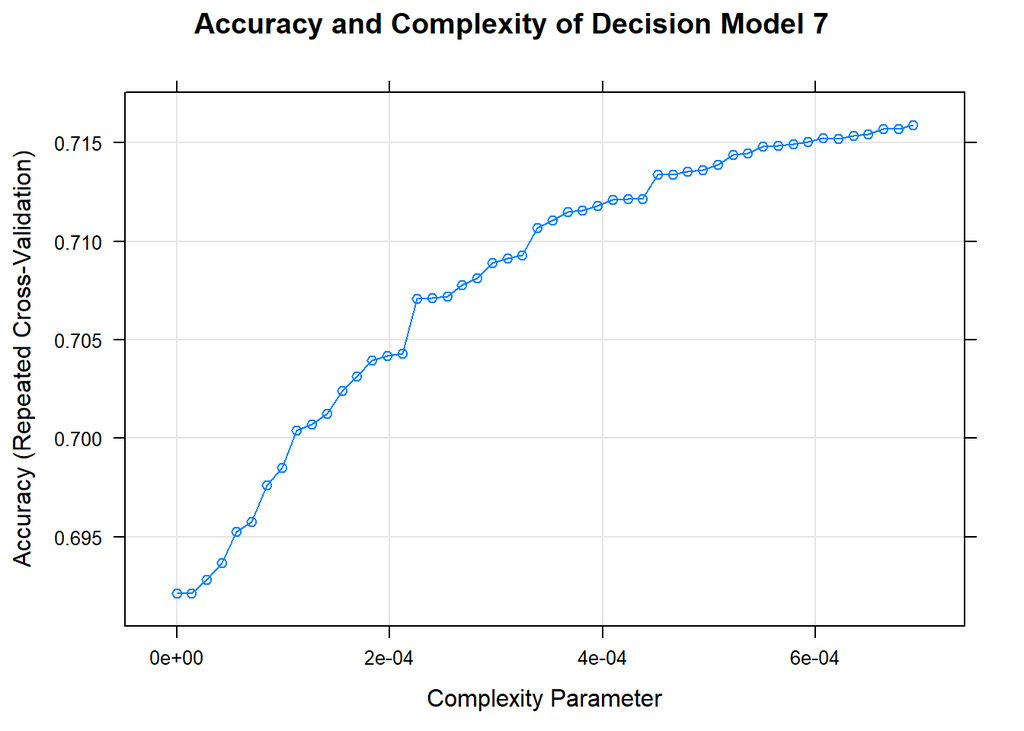

```r
plot(tree_model_07, main = "Accuracy and Complexity of Decision Model 7")
```

```r
#Testing Model
risk_pred_tree_model_07<- predict(tree_model_07, data_1_test)


#Statistics about model
data_1_test$risk_pred_tree_model_07<- risk_pred_tree_model_07
conf_matrix_tree_model_07<- table(data_1_test$Hood_Risk, data_1_test$risk_pred_tree_model_07)
conf_matrix_tree_model_07
```

```
##
##             Very Low  Low Medium High Very High
##   Very Low         0    0      0    0       124
##   Low              0    0      0    0       315
##   Medium           0    0      0    0       623
##   High             0    0      0    0      1076
##   Very High        0    0      0    0      5533
```

```r
class_accuarcy_tree_model_07<- sum(diag(conf_matrix_tree_model_07)/sum(conf_matrix_tree_model_07))
class_accuarcy_tree_model_07
```

```
## [1] 0.721288
```

```r
confusionMatrix(conf_matrix_tree_model_07)
```

```
## Confusion Matrix and Statistics
##
##
##             Very Low  Low Medium High Very High
##   Very Low         0    0      0    0       124
##   Low              0    0      0    0       315
##   Medium           0    0      0    0       623
##   High             0    0      0    0      1076
##   Very High        0    0      0    0      5533
##
## Overall Statistics
##
##                Accuracy : 0.7213
##                  95% CI : (0.7111, 0.7313)
##     No Information Rate : 1
##     P-Value [Acc > NIR] : 1
##
##                   Kappa : 0
##
##  Mcnemar's Test P-Value : NA
##
## Statistics by Class:
##
##                      Class: Very Low Class: Low Class: Medium Class: High
## Sensitivity                       NA         NA            NA          NA
## Specificity                  0.98384    0.95894       0.91879      0.8597
## Pos Pred Value                    NA         NA            NA          NA
## Neg Pred Value                    NA         NA            NA          NA
## Prevalence                   0.00000    0.00000       0.00000      0.0000
## Detection Rate               0.00000    0.00000       0.00000      0.0000
## Detection Prevalence         0.01616    0.04106       0.08121      0.1403
## Balanced Accuracy                 NA         NA            NA          NA
##                      Class: Very High
## Sensitivity                    0.7213
## Specificity                        NA
## Pos Pred Value                     NA
## Neg Pred Value                     NA
## Prevalence                     1.0000
## Detection Rate                 0.7213
## Detection Prevalence           0.7213
## Balanced Accuracy                  NA
```

```r
n_conf_matrix_tree_model_07 = sum(conf_matrix_tree_model_07)
nc_conf_matrix_tree_model_07 = nrow(conf_matrix_tree_model_07)
diag_conf_matrix_tree_model_07 = diag(conf_matrix_tree_model_07)
rowsums_conf_matrix_tree_model_07 = apply(conf_matrix_tree_model_07, 1, sum)
colsums_conf_matrix_tree_model_07 = apply(conf_matrix_tree_model_07, 2, sum)

precision_conf_matrix_tree_model_07 = diag_conf_matrix_tree_model_07 / colsums_conf_matrix_tree_model_07
recall_conf_matrix_tree_model_07 = diag_conf_matrix_tree_model_07 / rowsums_conf_matrix_tree_model_07
f1_conf_matrix_tree_model_07 = 2 * precision_conf_matrix_tree_model_07 * recall_conf_matrix_tree_model_07 / (precision_conf_matrix_tree_model_07 + recall_conf_matrix_tree_model_07)
data_frame_conf_matrix_tree_model_07<- data.frame(precision_conf_matrix_tree_model_07, recall_conf_matrix_tree_model_07, f1_conf_matrix_tree_model_07)
data_frame_conf_matrix_tree_model_07
```

```
##           precision_conf_matrix_tree_model_07 recall_conf_matrix_tree_model_07
## Very Low                                  NaN                                0
## Low                                       NaN                                0
## Medium                                    NaN                                0
## High                                      NaN                                0
## Very High                            0.721288                                1
##           f1_conf_matrix_tree_model_07
## Very Low                           NaN
## Low                                NaN
## Medium                             NaN
## High                               NaN
## Very High                    0.8380794
```

No Premises_Type+Occurrence_DayOfWeek+Occurrence_Date+Occurrence_Month + Location_Type + Occurrence_Hour + NeighbourhoodName Variables were used

```r
set.seed(999)
data_1<- bt_clean_future_selection

#Random Sampling
Index<- sample(nrow(data_1), floor(0.70*nrow(data_1)))
data_1_train<- data_1[Index,]
data_1_test<- data_1[-Index,]

#Treating train data
data_1_train$Cost_of_Bike[is.na(data_1_train$Cost_of_Bike)]<- mean(data_1_train$Cost_of_Bike,na.rm=TRUE)
data_1_train$Occurrence_Year[data_1_train$Occurrence_Year==2009] <- 2014
data_1_train$Occurrence_Year[data_1_train$Occurrence_Year==2010] <- 2014
data_1_train$Occurrence_Year[data_1_train$Occurrence_Year==2011] <- 2014
data_1_train$Occurrence_Year[data_1_train$Occurrence_Year==2012] <- 2014
data_1_train$Occurrence_Year[data_1_train$Occurrence_Year==2013] <- 2014

ctrl<- trainControl(method = "repeatedcv", number = 10 ,repeats = 10)

tree_model_08 <- train(Hood_Risk ~ Hood_ID + Division, data = data_1_train, method = "rpart", trControl = ctrl, tuneLength = 50)

print(tree_model_08)
```

```
## CART
##
## 17898 samples
##     2 predictor
##     5 classes: 'Very Low', 'Low', 'Medium', 'High', 'Very High'
##
## No pre-processing
## Resampling: Cross-Validated (10 fold, repeated 10 times)
## Summary of sample sizes: 16109, 16109, 16109, 16108, 16109, 16107, ...
## Resampling results across tuning parameters:
##
##   cp           Accuracy   Kappa
##   0.000000000  0.9978713  0.9953306
##   0.003727445  0.9747681  0.9445016
##   0.007454889  0.9313164  0.8456050
##   0.011182334  0.9192981  0.8193805
##   0.014909779  0.9063024  0.7884606
##   0.018637224  0.8696503  0.6995076
##   0.022364668  0.8446188  0.6374048
##   0.026092113  0.8337516  0.6171767
##   0.029819558  0.7986980  0.5400202
##   0.033547003  0.7966423  0.5333423
##   0.037274447  0.7837972  0.5014048
##   0.041001892  0.7836911  0.5011467
##   0.044729337  0.7836911  0.5011467
##   0.048456781  0.7824562  0.4981694
##   0.052184226  0.7705166  0.4694394
##   0.055911671  0.7689687  0.4657065
##   0.059639116  0.7689687  0.4657065
##   0.063366560  0.7689687  0.4657065
##   0.067094005  0.7689687  0.4657065
##   0.070821450  0.7689687  0.4657065
##   0.074548894  0.7689687  0.4657065
##   0.078276339  0.7689687  0.4657065
##   0.082003784  0.7689687  0.4657065
##   0.085731229  0.7689687  0.4657065
##   0.089458673  0.7689687  0.4657065
##   0.093186118  0.7689687  0.4657065
##   0.096913563  0.7689687  0.4657065
##   0.100641008  0.7689687  0.4657065
```

[output cut: 10 more lines]

```
##   0.141642900  0.7689687  0.4657065
##   0.145370344  0.7689687  0.4657065
##   0.149097789  0.7689687  0.4657065
##   0.152825234  0.7689687  0.4657065
##   0.156552678  0.7689687  0.4657065
##   0.160280123  0.7689687  0.4657065
##   0.164007568  0.7689687  0.4657065
##   0.167735013  0.7689687  0.4657065
##   0.171462457  0.7689687  0.4657065
##   0.175189902  0.7689687  0.4657065
##   0.178917347  0.7657955  0.4411446
##   0.182644791  0.7401503  0.2228978
##
## Accuracy was used to select the optimal model using the largest value.
## The final value used for the model was cp = 0.
```

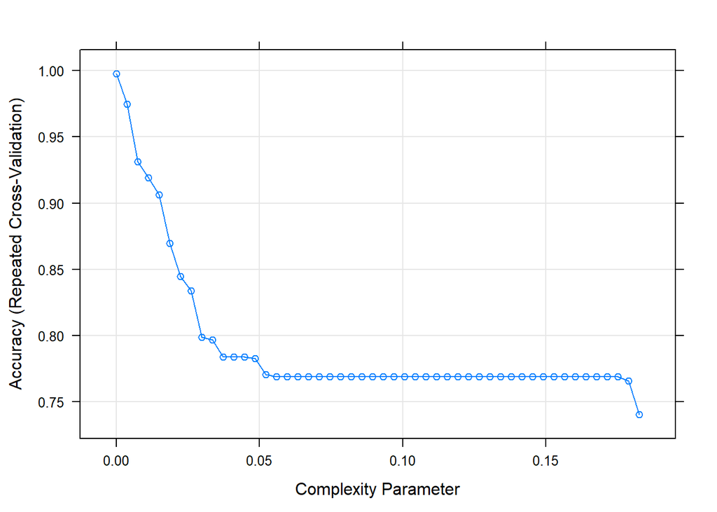

```r
plot(tree_model_08)
```

```r
#Testing Model
risk_pred_tree_model_08<- predict(tree_model_08, data_1_test)


#Statistics about model
data_1_test$risk_pred_tree_model_08<- risk_pred_tree_model_08
conf_matrix_tree_model_08<- table(data_1_test$Hood_Risk, data_1_test$risk_pred_tree_model_08)
conf_matrix_tree_model_08
```

```
##
##             Very Low  Low Medium High Very High
##   Very Low       109    2      9    4         0
##   Low              0  311      2    2         0
##   Medium           0    0    623    0         0
##   High             0    0      0 1076         0
##   Very High        0    0      0    1      5532
```

```r
class_accuarcy_tree_model_08<- sum(diag(conf_matrix_tree_model_08)/sum(conf_matrix_tree_model_08))
class_accuarcy_tree_model_08
```

```
## [1] 0.9973928
```

```r
confusionMatrix(conf_matrix_tree_model_08)
```

```
## Confusion Matrix and Statistics
##
##
##             Very Low  Low Medium High Very High
##   Very Low       109    2      9    4         0
##   Low              0  311      2    2         0
##   Medium           0    0    623    0         0
##   High             0    0      0 1076         0
##   Very High        0    0      0    1      5532
##
## Overall Statistics
##
##                Accuracy : 0.9974
##                  95% CI : (0.996, 0.9984)
##     No Information Rate : 0.7212
##     P-Value [Acc > NIR] : < 2.2e-16
##
##                   Kappa : 0.9942
##
##  Mcnemar's Test P-Value : NA
##
## Statistics by Class:
##
##                      Class: Very Low Class: Low Class: Medium Class: High
## Sensitivity                  1.00000    0.99361       0.98265      0.9935
## Specificity                  0.99802    0.99946       1.00000      1.0000
## Pos Pred Value               0.87903    0.98730       1.00000      1.0000
## Neg Pred Value               1.00000    0.99973       0.99844      0.9989
## Prevalence                   0.01421    0.04080       0.08265      0.1412
## Detection Rate               0.01421    0.04054       0.08121      0.1403
## Detection Prevalence         0.01616    0.04106       0.08121      0.1403
## Balanced Accuracy            0.99901    0.99653       0.99132      0.9968
##                      Class: Very High
## Sensitivity                    1.0000
## Specificity                    0.9995
## Pos Pred Value                 0.9998
## Neg Pred Value                 1.0000
## Prevalence                     0.7212
## Detection Rate                 0.7212
## Detection Prevalence           0.7213
## Balanced Accuracy              0.9998
```

No Premises_Type+Occurrence_DayOfWeek+Occurrence_Date+Occurrence_Month + Location_Type + Occurrence_Hour + Hood_ID Variables were used

```r
set.seed(999)
data_1<- bt_clean_future_selection

#Random Sampling
Index<- sample(nrow(data_1), floor(0.70*nrow(data_1)))
data_1_train<- data_1[Index,]
data_1_test<- data_1[-Index,]

#Treating train data
data_1_train$Cost_of_Bike[is.na(data_1_train$Cost_of_Bike)]<- mean(data_1_train$Cost_of_Bike,na.rm=TRUE)
data_1_train$Occurrence_Year[data_1_train$Occurrence_Year==2009] <- 2014
data_1_train$Occurrence_Year[data_1_train$Occurrence_Year==2010] <- 2014
data_1_train$Occurrence_Year[data_1_train$Occurrence_Year==2011] <- 2014
data_1_train$Occurrence_Year[data_1_train$Occurrence_Year==2012] <- 2014
data_1_train$Occurrence_Year[data_1_train$Occurrence_Year==2013] <- 2014

ctrl<- trainControl(method = "repeatedcv", number = 10 ,repeats = 10)

tree_model_09 <- train(Hood_Risk ~ NeighbourhoodName + Division, data = data_1_train, method = "rpart", trControl = ctrl, tuneLength = 50)

print(tree_model_09)
```

```
## CART
##
## 17898 samples
##     2 predictor
##     5 classes: 'Very Low', 'Low', 'Medium', 'High', 'Very High'
##
## No pre-processing
## Resampling: Cross-Validated (10 fold, repeated 10 times)
## Summary of sample sizes: 16109, 16109, 16109, 16108, 16109, 16107, ...
## Resampling results across tuning parameters:
##
##   cp           Accuracy   Kappa
##   0.000000000  0.9976813  0.99491205
##   0.001750769  0.9954465  0.99000518
##   0.003501539  0.9776342  0.95071585
##   0.005252308  0.9614872  0.91493745
##   0.007003078  0.9455639  0.87903275
##   0.008753847  0.9381666  0.86245317
##   0.010504617  0.9243661  0.83230422
##   0.012255386  0.9205947  0.82402662
##   0.014006156  0.9127168  0.80560392
##   0.015756925  0.9058000  0.78922636
##   0.017507695  0.8957814  0.76690519
##   0.019258464  0.8658895  0.68629937
##   0.021009234  0.8119798  0.50129084
##   0.022760003  0.7991619  0.44764517
##   0.024510773  0.7991619  0.44764517
##   0.026261542  0.7989607  0.44673476
##   0.028012312  0.7986200  0.44512881
##   0.029763081  0.7964744  0.43403433
##   0.031513851  0.7825343  0.35807981
##   0.033264620  0.7815790  0.35313628
##   0.035015390  0.7798192  0.34995039
##   0.036766159  0.7742988  0.33984711
##   0.038516929  0.7714829  0.33465365
##   0.040267698  0.7714829  0.33465365
##   0.042018468  0.7714829  0.33465365
##   0.043769237  0.7714829  0.33465365
##   0.045520007  0.7714829  0.33465365
##   0.047270776  0.7714829  0.33465365
```

[output cut: 10 more lines]

```
##   0.066529241  0.7415913  0.15118865
##   0.068280010  0.7415913  0.15118865
##   0.070030780  0.7415913  0.15118865
##   0.071781549  0.7415913  0.15118865
##   0.073532319  0.7415913  0.15118865
##   0.075283088  0.7415913  0.15118865
##   0.077033858  0.7415913  0.15118865
##   0.078784627  0.7415913  0.15118865
##   0.080535397  0.7415913  0.15118865
##   0.082286166  0.7415913  0.15118865
##   0.084036936  0.7385412  0.13311122
##   0.085787705  0.7290531  0.07519322
##
## Accuracy was used to select the optimal model using the largest value.
## The final value used for the model was cp = 0.
```

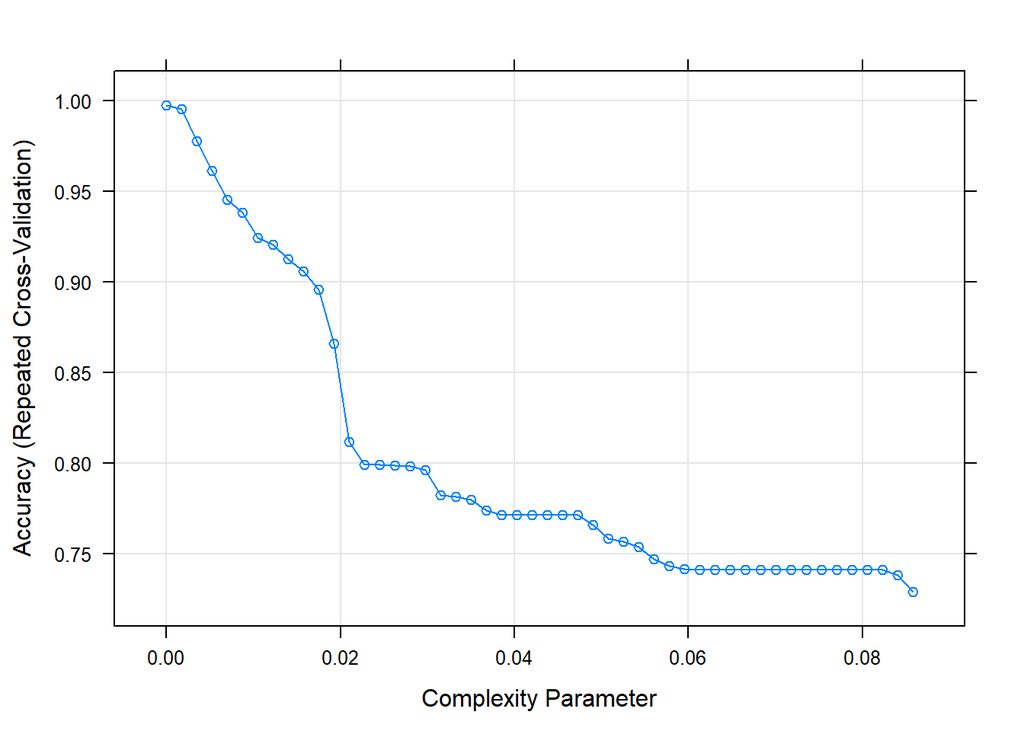

```r
plot(tree_model_09)
```

```r
#Testing Model
risk_pred_tree_model_09<- predict(tree_model_09, data_1_test)


#Statistics about model
data_1_test$risk_pred_tree_model_09<- risk_pred_tree_model_09
conf_matrix_tree_model_09<- table(data_1_test$Hood_Risk, data_1_test$risk_pred_tree_model_09)
conf_matrix_tree_model_09
```

```
##
##             Very Low  Low Medium High Very High
##   Very Low       121    0      0    3         0
##   Low              5  309      1    0         0
##   Medium           1    0    621    1         0
##   High             0    0      0 1076         0
##   Very High        0    0      1    2      5530
```

```r
class_accuarcy_tree_model_09<- sum(diag(conf_matrix_tree_model_09)/sum(conf_matrix_tree_model_09))
class_accuarcy_tree_model_09
```

```
## [1] 0.9981749
```

```r
confusionMatrix(conf_matrix_tree_model_09)
```

```
## Confusion Matrix and Statistics
##
##
##             Very Low  Low Medium High Very High
##   Very Low       121    0      0    3         0
##   Low              5  309      1    0         0
##   Medium           1    0    621    1         0
##   High             0    0      0 1076         0
##   Very High        0    0      1    2      5530
##
## Overall Statistics
##
##                Accuracy : 0.9982
##                  95% CI : (0.9969, 0.999)
##     No Information Rate : 0.7209
##     P-Value [Acc > NIR] : < 2.2e-16
##
##                   Kappa : 0.996
##
##  Mcnemar's Test P-Value : NA
##
## Statistics by Class:
##
##                      Class: Very Low Class: Low Class: Medium Class: High
## Sensitivity                  0.95276    1.00000       0.99679      0.9945
## Specificity                  0.99960    0.99919       0.99972      1.0000
## Pos Pred Value               0.97581    0.98095       0.99679      1.0000
## Neg Pred Value               0.99920    1.00000       0.99972      0.9991
## Prevalence                   0.01656    0.04028       0.08121      0.1411
## Detection Rate               0.01577    0.04028       0.08095      0.1403
## Detection Prevalence         0.01616    0.04106       0.08121      0.1403
## Balanced Accuracy            0.97618    0.99959       0.99825      0.9972
##                      Class: Very High
## Sensitivity                    1.0000
## Specificity                    0.9986
## Pos Pred Value                 0.9995
## Neg Pred Value                 1.0000
## Prevalence                     0.7209
## Detection Rate                 0.7209
## Detection Prevalence           0.7213
## Balanced Accuracy              0.9993
```

No Premises_Type+Occurrence_DayOfWeek+Occurrence_Date+Occurrence_Month + Occurrence_Hour + Hood_ID were used

```r
set.seed(999)
data_1<- bt_clean_future_selection

#Random Sampling
Index<- sample(nrow(data_1), floor(0.70*nrow(data_1)))
data_1_train<- data_1[Index,]
data_1_test<- data_1[-Index,]

#Treating train data
data_1_train$Cost_of_Bike[is.na(data_1_train$Cost_of_Bike)]<- mean(data_1_train$Cost_of_Bike,na.rm=TRUE)
data_1_train$Occurrence_Year[data_1_train$Occurrence_Year==2009] <- 2014
data_1_train$Occurrence_Year[data_1_train$Occurrence_Year==2010] <- 2014
data_1_train$Occurrence_Year[data_1_train$Occurrence_Year==2011] <- 2014
data_1_train$Occurrence_Year[data_1_train$Occurrence_Year==2012] <- 2014
data_1_train$Occurrence_Year[data_1_train$Occurrence_Year==2013] <- 2014

ctrl<- trainControl(method = "repeatedcv", number = 10 ,repeats = 10)

tree_model_10 <- train(Hood_Risk ~ NeighbourhoodName + Location_Type, data = data_1_train, method = "rpart", trControl = ctrl, tuneLength = 50)

print(tree_model_10)
```

```
## CART
##
## 17898 samples
##     2 predictor
##     5 classes: 'Very Low', 'Low', 'Medium', 'High', 'Very High'
##
## No pre-processing
## Resampling: Cross-Validated (10 fold, repeated 10 times)
## Summary of sample sizes: 16109, 16109, 16109, 16108, 16109, 16107, ...
## Resampling results across tuning parameters:
##
##   cp            Accuracy   Kappa
##   0.0000000000  0.8538159  0.63197817
##   0.0002307466  0.8538159  0.63197817
##   0.0004614932  0.8538159  0.63197817
##   0.0006922397  0.8538159  0.63197817
##   0.0009229863  0.8538159  0.63197817
##   0.0011537329  0.8538159  0.63197817
##   0.0013844795  0.8538159  0.63197817
##   0.0016152260  0.8538159  0.63197817
##   0.0018459726  0.8538159  0.63197817
##   0.0020767192  0.8538159  0.63197817
##   0.0023074658  0.8538159  0.63197817
##   0.0025382124  0.8538159  0.63197817
##   0.0027689589  0.8538159  0.63197817
##   0.0029997055  0.8523355  0.62500534
##   0.0032304521  0.8523355  0.62500534
##   0.0034611987  0.8512238  0.61940943
##   0.0036919453  0.8458247  0.59170733
##   0.0039226918  0.8354766  0.53866456
##   0.0041534384  0.8324034  0.52271386
##   0.0043841850  0.8324034  0.52271386
##   0.0046149316  0.8324034  0.52271386
##   0.0048456781  0.8324034  0.52271386
##   0.0050764247  0.8311911  0.51684257
##   0.0053071713  0.8180277  0.45252277
##   0.0055379179  0.8096304  0.41125463
##   0.0057686645  0.8084565  0.40537246
##   0.0059994110  0.8073560  0.39985257
##   0.0062301576  0.8073560  0.39985257
```

[output cut: 10 more lines]

```
##   0.0087683700  0.7268947  0.04269544
##   0.0089991165  0.7268947  0.04269544
##   0.0092298631  0.7268947  0.04269544
##   0.0094606097  0.7268947  0.04269544
##   0.0096913563  0.7268947  0.04269544
##   0.0099221029  0.7268947  0.04269544
##   0.0101528494  0.7268947  0.04269544
##   0.0103835960  0.7268947  0.04269544
##   0.0106143426  0.7268947  0.04269544
##   0.0108450892  0.7268947  0.04269544
##   0.0110758358  0.7268947  0.04269544
##   0.0113065823  0.7260789  0.03834181
##
## Accuracy was used to select the optimal model using the largest value.
## The final value used for the model was cp = 0.002768959.
```

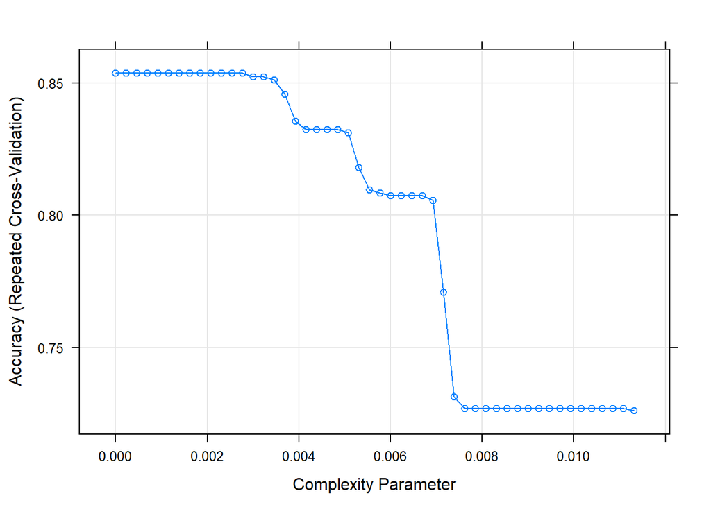

```r
plot(tree_model_10)
```

```r
#Testing Model
risk_pred_tree_model_10<- predict(tree_model_10, data_1_test)


#Statistics about model
data_1_test$risk_pred_tree_model_10<- risk_pred_tree_model_10
conf_matrix_tree_model_10<- table(data_1_test$Hood_Risk, data_1_test$risk_pred_tree_model_10)
conf_matrix_tree_model_10
```

```
##
##             Very Low  Low Medium High Very High
##   Very Low         0    0      0    0       124
##   Low              0    0      0    0       315
##   Medium           0    0      0    0       623
##   High             0    0      0 1043        33
##   Very High        0    0      0    0      5533
```

```r
class_accuarcy_tree_model_10<- sum(diag(conf_matrix_tree_model_10)/sum(conf_matrix_tree_model_10))
class_accuarcy_tree_model_10
```

```
## [1] 0.8572546
```

```r
confusionMatrix(conf_matrix_tree_model_10)
```

```
## Confusion Matrix and Statistics
##
##
##             Very Low  Low Medium High Very High
##   Very Low         0    0      0    0       124
##   Low              0    0      0    0       315
##   Medium           0    0      0    0       623
##   High             0    0      0 1043        33
##   Very High        0    0      0    0      5533
##
## Overall Statistics
##
##                Accuracy : 0.8573
##                  95% CI : (0.8492, 0.865)
##     No Information Rate : 0.864
##     P-Value [Acc > NIR] : 0.9591
##
##                   Kappa : 0.6009
##
##  Mcnemar's Test P-Value : NA
##
## Statistics by Class:
##
##                      Class: Very Low Class: Low Class: Medium Class: High
## Sensitivity                       NA         NA            NA      1.0000
## Specificity                  0.98384    0.95894       0.91879      0.9950
## Pos Pred Value                    NA         NA            NA      0.9693
## Neg Pred Value                    NA         NA            NA      1.0000
## Prevalence                   0.00000    0.00000       0.00000      0.1360
## Detection Rate               0.00000    0.00000       0.00000      0.1360
## Detection Prevalence         0.01616    0.04106       0.08121      0.1403
## Balanced Accuracy                 NA         NA            NA      0.9975
##                      Class: Very High
## Sensitivity                    0.8348
## Specificity                    1.0000
## Pos Pred Value                 1.0000
## Neg Pred Value                 0.4878
## Prevalence                     0.8640
## Detection Rate                 0.7213
## Detection Prevalence           0.7213
## Balanced Accuracy              0.9174
```

No Premises_Type+Occurrence_DayOfWeek+Occurrence_Date+Occurrence_Month + Hood_ID were used

```r
set.seed(999)
data_1<- bt_clean_future_selection

#Random Sampling
Index<- sample(nrow(data_1), floor(0.70*nrow(data_1)))
data_1_train<- data_1[Index,]
data_1_test<- data_1[-Index,]

#Treating train data
data_1_train$Cost_of_Bike[is.na(data_1_train$Cost_of_Bike)]<- mean(data_1_train$Cost_of_Bike,na.rm=TRUE)
data_1_train$Occurrence_Year[data_1_train$Occurrence_Year==2009] <- 2014
data_1_train$Occurrence_Year[data_1_train$Occurrence_Year==2010] <- 2014
data_1_train$Occurrence_Year[data_1_train$Occurrence_Year==2011] <- 2014
data_1_train$Occurrence_Year[data_1_train$Occurrence_Year==2012] <- 2014
data_1_train$Occurrence_Year[data_1_train$Occurrence_Year==2013] <- 2014

ctrl<- trainControl(method = "repeatedcv", number = 10 ,repeats = 10)

tree_model_11 <- train(Hood_Risk ~ NeighbourhoodName + Location_Type + Occurrence_Hour, data = data_1_train, method = "rpart", trControl = ctrl, tuneLength = 50)

print(tree_model_11)
```

```
## CART
##
## 17898 samples
##     3 predictor
##     5 classes: 'Very Low', 'Low', 'Medium', 'High', 'Very High'
##
## No pre-processing
## Resampling: Cross-Validated (10 fold, repeated 10 times)
## Summary of sample sizes: 16109, 16109, 16109, 16108, 16109, 16107, ...
## Resampling results across tuning parameters:
##
##   cp            Accuracy   Kappa
##   0.0000000000  0.8538159  0.63197817
##   0.0002307466  0.8538159  0.63197817
##   0.0004614932  0.8538159  0.63197817
##   0.0006922397  0.8538159  0.63197817
##   0.0009229863  0.8538159  0.63197817
##   0.0011537329  0.8538159  0.63197817
##   0.0013844795  0.8538159  0.63197817
##   0.0016152260  0.8538159  0.63197817
##   0.0018459726  0.8538159  0.63197817
##   0.0020767192  0.8538159  0.63197817
##   0.0023074658  0.8538159  0.63197817
##   0.0025382124  0.8538159  0.63197817
##   0.0027689589  0.8538159  0.63197817
##   0.0029997055  0.8523355  0.62500534
##   0.0032304521  0.8523355  0.62500534
##   0.0034611987  0.8512238  0.61940943
##   0.0036919453  0.8458247  0.59170733
##   0.0039226918  0.8354766  0.53866456
##   0.0041534384  0.8324034  0.52271386
##   0.0043841850  0.8324034  0.52271386
##   0.0046149316  0.8324034  0.52271386
##   0.0048456781  0.8324034  0.52271386
##   0.0050764247  0.8311911  0.51684257
##   0.0053071713  0.8180277  0.45252277
##   0.0055379179  0.8096304  0.41125463
##   0.0057686645  0.8084565  0.40537246
##   0.0059994110  0.8073560  0.39985257
##   0.0062301576  0.8073560  0.39985257
```

[output cut: 10 more lines]

```
##   0.0087683700  0.7268947  0.04269544
##   0.0089991165  0.7268947  0.04269544
##   0.0092298631  0.7268947  0.04269544
##   0.0094606097  0.7268947  0.04269544
##   0.0096913563  0.7268947  0.04269544
##   0.0099221029  0.7268947  0.04269544
##   0.0101528494  0.7268947  0.04269544
##   0.0103835960  0.7268947  0.04269544
##   0.0106143426  0.7268947  0.04269544
##   0.0108450892  0.7268947  0.04269544
##   0.0110758358  0.7268947  0.04269544
##   0.0113065823  0.7260789  0.03834181
##
## Accuracy was used to select the optimal model using the largest value.
## The final value used for the model was cp = 0.002768959.
```